# Income in the U.S.

2020-05-03

# Introduction

America is a highly diverse country. It is not only diverse in terms of ethnicity, but also in terms of income, industry, and law. This opens the doors for a variety of possible interactions between these variables. What factors drive the way that income is distributed in the United States? What factors reliably predict whether the average income per capita in a given area is high or low? In this analysis, several models were used to persue these questions, and also investigate how these models differ in the ways that they answer these questions.

## How are these questions SMART?

These questions are important because they tell many facets of the story of consumption in the United States. Income serves both as a measure of productivity and lifetime consumption (although this analysis does not disentangle the two). Although their scope is broad, they remain specific to the concepts of income and demographics and they maintain a consistent structure: how do demographics (both economic and ethnic) drive income in the United States, at the census tract level.

These questions also correspond to a set of highly measurable (and luckily, premeasured) variables. Income can be imputed from tax records, while ethnicity and work status are available from census forms. Achieving the answers to the questions is made simple by the cleanliness and availability of this data; since few data points are missing across all census tracts throughout the 50 states of interest, it is simple to form statistical tests.

Finally, these questions are relevant to policy makers who want to improve the incomes of their constituents as well as to researchers interested in establishing a baseline for the average income they should expect a community would earn based on its demographics. These are critical questions, because the ability of communities to support themselves economically has massive impacts on the wellbeing of their members.

## Content

First, an examination is conducted on how the US Census Bureau database is structured, and which variables were included. Secondly, the groups of independent variables and how each of them could affect the income per capita of a community is presented. Then, an exploratory data analysis and some statistical tests are made to evaluate the significance of the variables. Later on, the models are executed, including clustering, classification, and regression. Finally, a conclusion looks into further challenges and questions necessary to enhance future analyses.

# Dataset

## U.S. Census Bureau Dataset

The U.S. Census Bureau Data holds the yearly American Community Survey: a project which asks Americans around the country about several dimensions of their lives, including work, income, demographics, and other activities (U.S. Census Bureau, 2019). The dataset from 2015 was available via Kaggle (MuonNeutrino, 2015), and included more than 74,000 observations, with 37 columns (variables). The dataset includes two variables related to income: the median household income and income per capita. The variable income per capita was prefered because it adjusts per person, and not per household given that it’s unknown how many people can live in an average household. The variable income per capita (IncomePerCap) is calculated as the average income per capita of the population of a specific census tract. But, what is a census tract and why use them?

### Census tracts

Household’s income in America varies significantly by geographical location. The richest counties in the country are concentrated in urban areas near big metropolises where most businesses are located. The bay area in northern California, Northeast Virginia and New York are some examples. However, counties have been an insufficient unit to compare different variables among them. There are 3,142 counties in a country of 300 million inhabitants (U.S. Census Bureau, 2019), but among them are several inconsistencies. Texas, for example, has 254 counties (U.S. Census Bureau, 2017). California, a state with approximately 10 million people more than Texas, has only 58 counties (U.S. Census Bureau, 2017). Population-wise California has the largest county in the country with more than 10 million inhabitants (Los Angeles), whereas Texas has more than 80 counties with less than 10,000 people (U.S. Census Bureau, 2017). Density-wise, New York has 4 of 5 of the most dense counties in the country, some of them 60,000 times more dense than counties in Hawaii, Alaska or Nevada (U.S. Census Bureau, 2013). As a response to these inconsistencies found in counties in America, the U.S. Census Bureau delineated “Census Tracts” at the beginning of the twentieth century. A census tract is “geographic region defined for the purpose of taking a census.” Over the years, the U.S. Census Bureau has established census tracts in every county in America. There are over 74,000 census tracts in the country and a typical one has around 4,000 or so residents. There is a strength that comes from this consistency: census tracts are by and large similar in population size, and the population size of census tracts does not vary much from state to state.

# Description of Variables

The complete dataset includes 12 relevant independent variables and 1 dependent variable. Thanks to their nature, the independent variables were classified in two groups: Work Variation and Ethnic Variation.

## Work Variation:

**Professional:** Percentage (%) employed in management, business, science, and arts in a census tract.

**Service:** Percentage (%) employed in service jobs in a census tract.

**Office:** Percentage (%) employed in sales and office jobs in a census tract.

**Construction:** Percentage (%) employed in natural resources, construction, and maintenance in a census tract.

**Production:** Percentage (%) employed in production, transportation, and material movement in a census tract.

**Unemployed:** Unemployment rate (%) in a census tract.

**Self-employed:** Percentage (%) self-employed in a census tract.

## Ethnic Variation

**Native:** Percentage (%) of population that is Native American or Native Alaskan in a census tract.

**White:** Percentage (%) of population that is white in a census tract.

**Black:** Percentage (%) of population that is black in a census tract.

**Hispanic:** Percentage (%) of population that is Hispanic/Latino in a census tract.

**Asian:** Percentage (%) of population that is Asian in a census tract.

# EDA

The exploratory data analysis of this dataset was divided into 4 sections:

- Population of census tracts
- Income per capita
- Independent variables
- Correlation matrix

## Population of census tracts

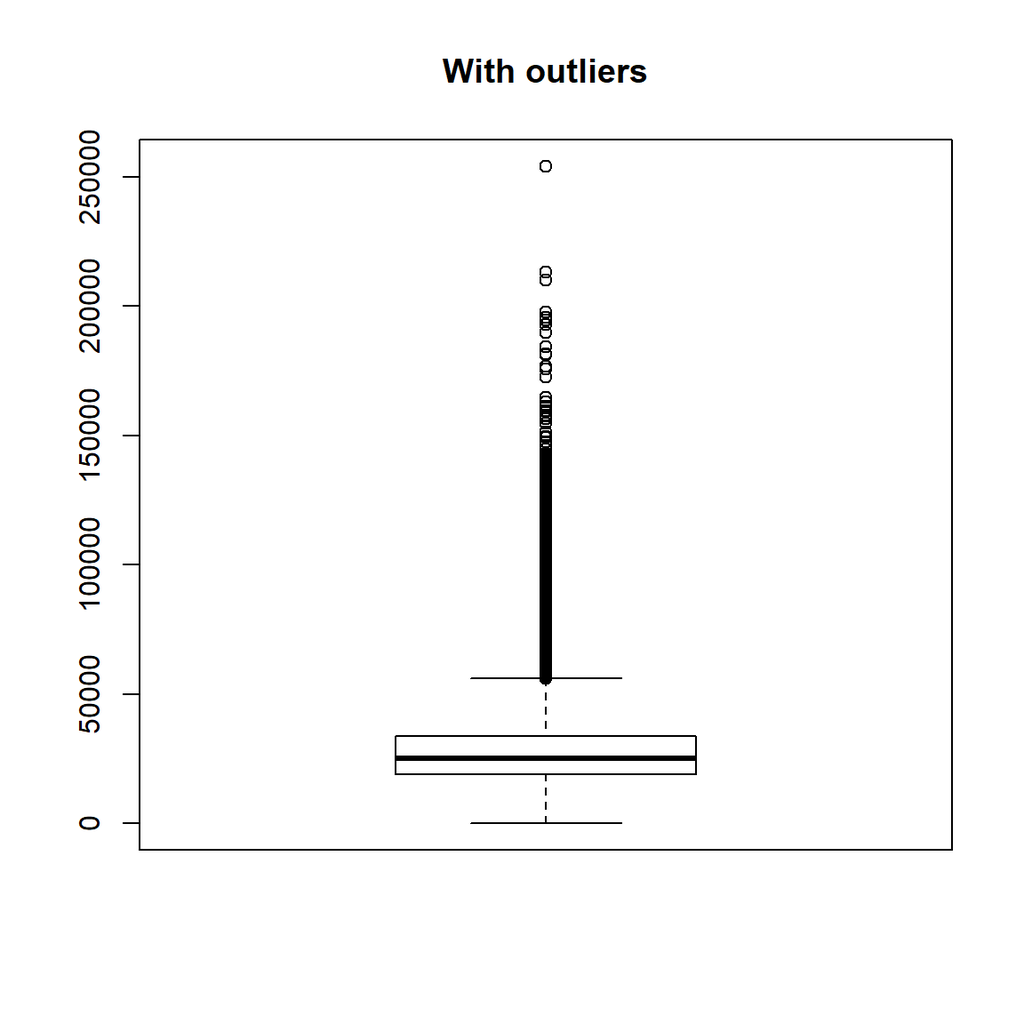

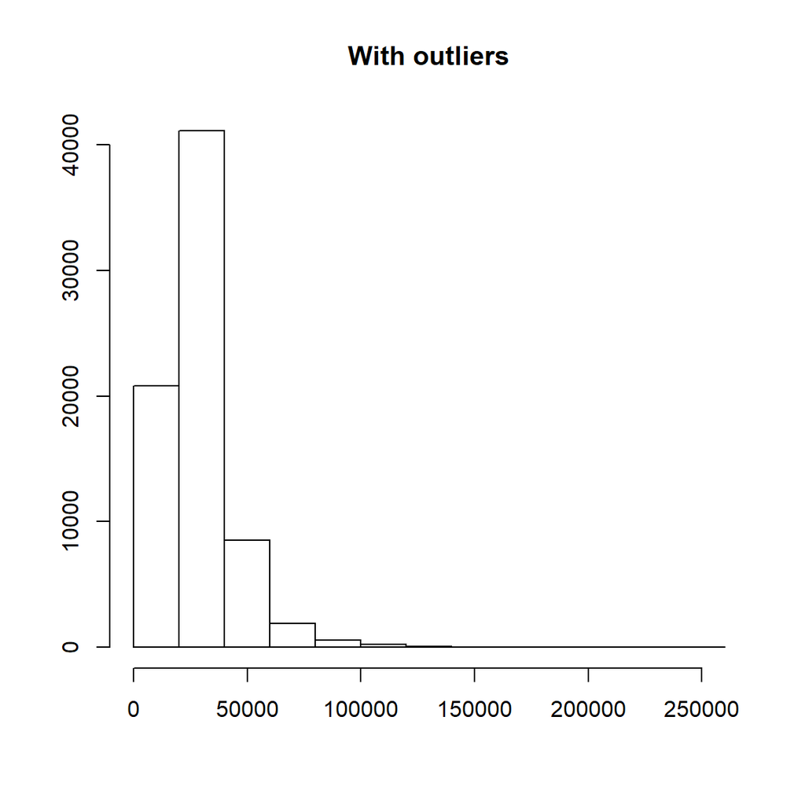

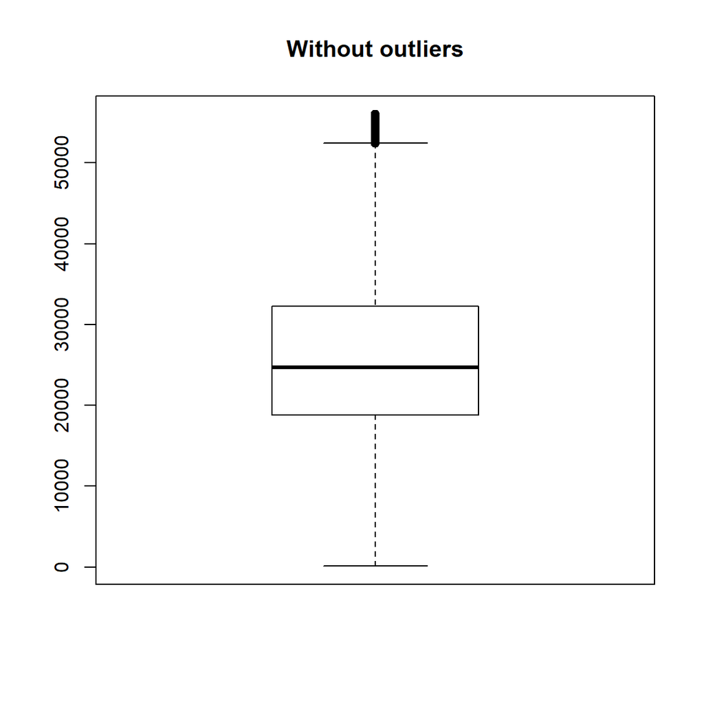

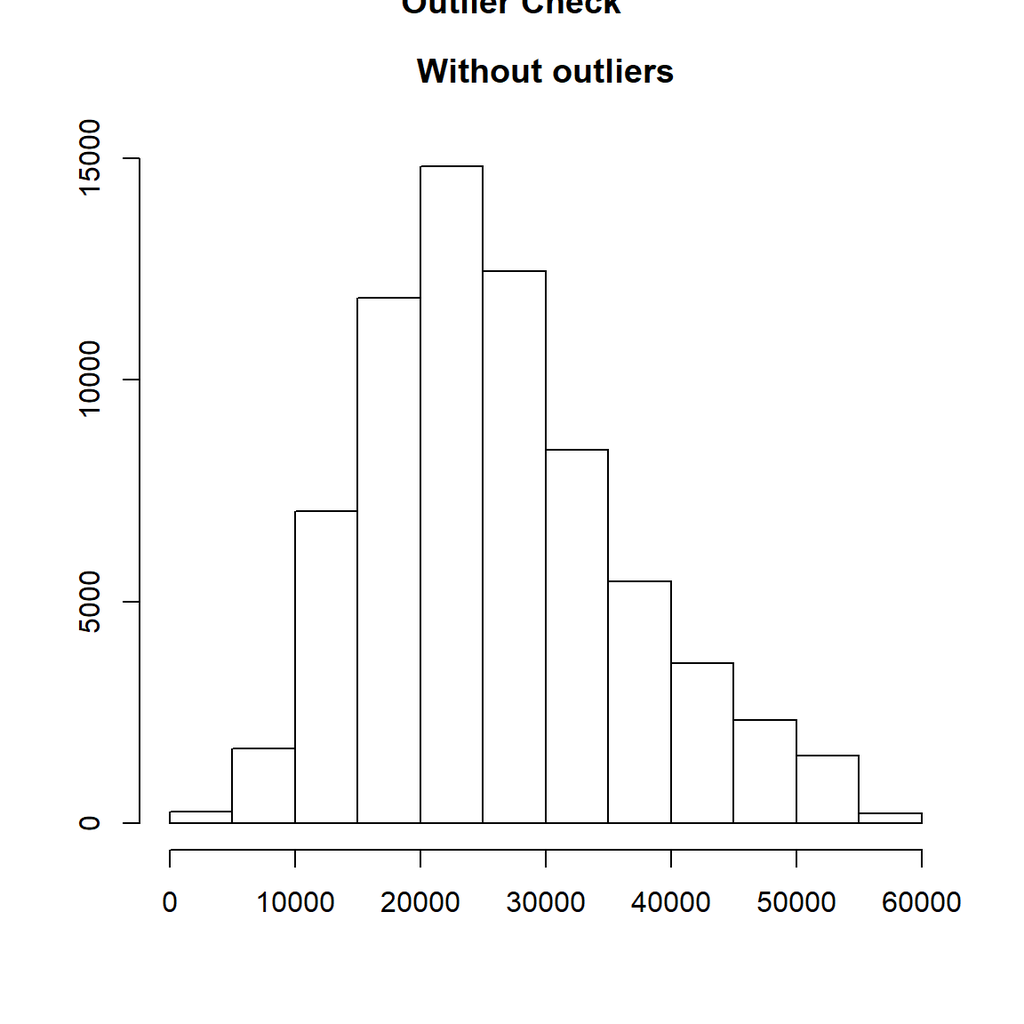

```
Outliers identified: 3589
Propotion (%) of outliers: 5.2
Mean of the outliers: 74140.26
Mean without removing outliers: 28491.23
Mean if we remove outliers: 26139.73
Outliers successfully removed
```

```
   Min. 1st Qu.  Median    Mean 3rd Qu.    Max.
      5    2929    4086    4369    5460   53812
```

## Income per capita

```
   Min. 1st Qu.  Median    Mean 3rd Qu.    Max.
    128   18776   24730   26140   32247   56040
```

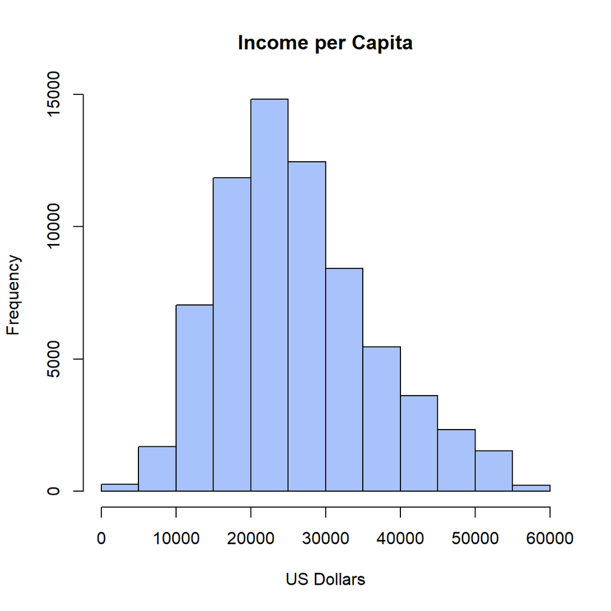

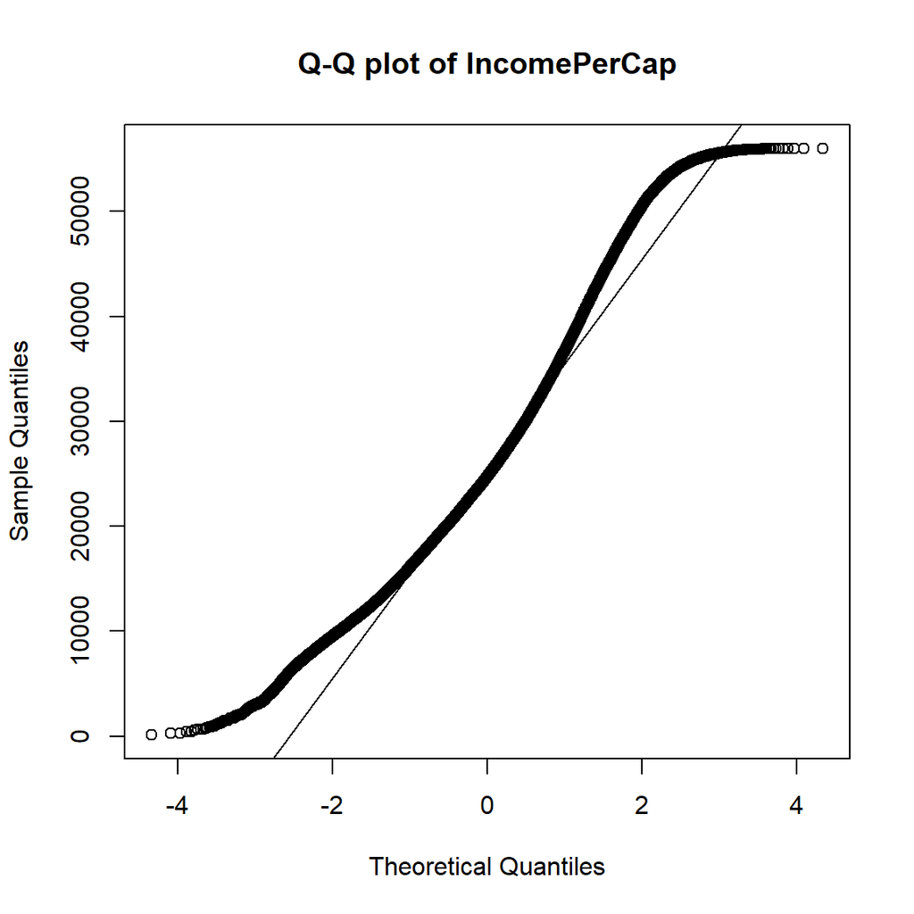

Outliers and NA’s were removed from our dependent variable income per capita. Note that the histogram appears normal, tails of q-q are closer to the line, and mean and median are much closer together. Outliers were taken out of this variable because super wealthy individuals could have been exercising a significant pull on the distribution .

## Independent variables

### Work variation

Next the seven variables for work variations (professional, production, unemployment, office, service, construction, self-employed) were assessed for normality.

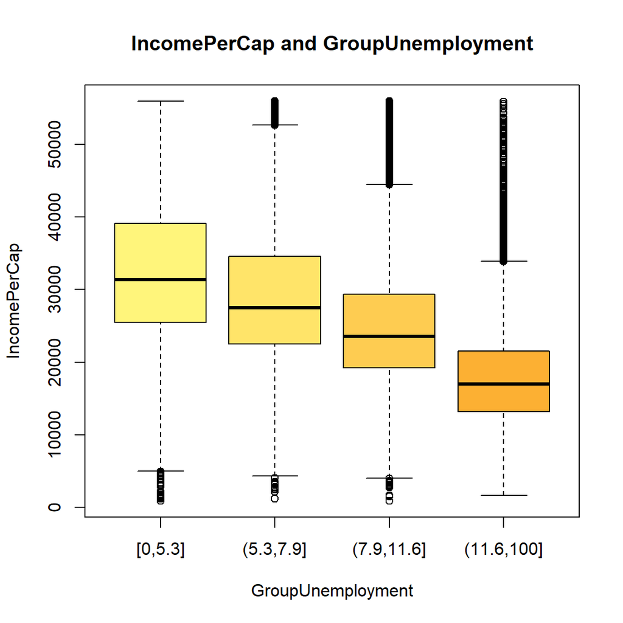

```
   Min. 1st Qu.  Median    Mean 3rd Qu.    Max.    NA's
  0.000   5.300   7.900   9.251  11.600 100.000     101
```

The boxplots that exhibited a decrease in income, as more of the specific work variation was included in the census tract, were unemployment, service, construction, and production. That is to say, as more unemployed individuals were accounted for in a given census tract, the income per capita decreased.

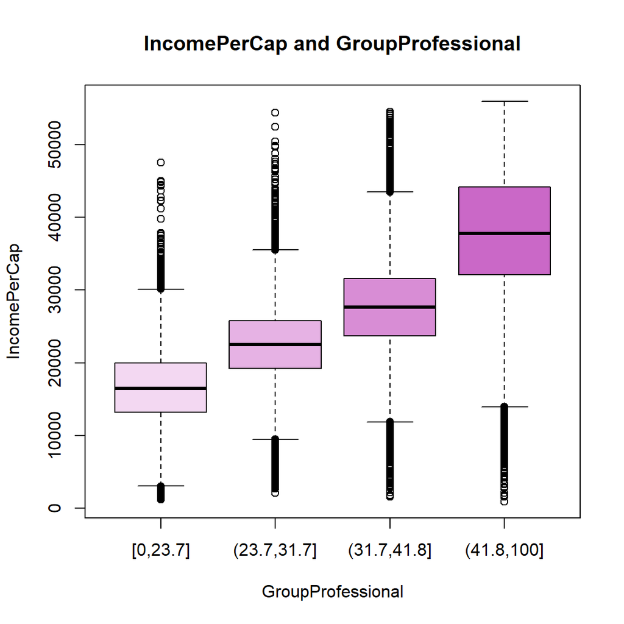

```
   Min. 1st Qu.  Median    Mean 3rd Qu.    Max.    NA's
   0.00   23.70   31.70   33.23   41.80  100.00     105
```

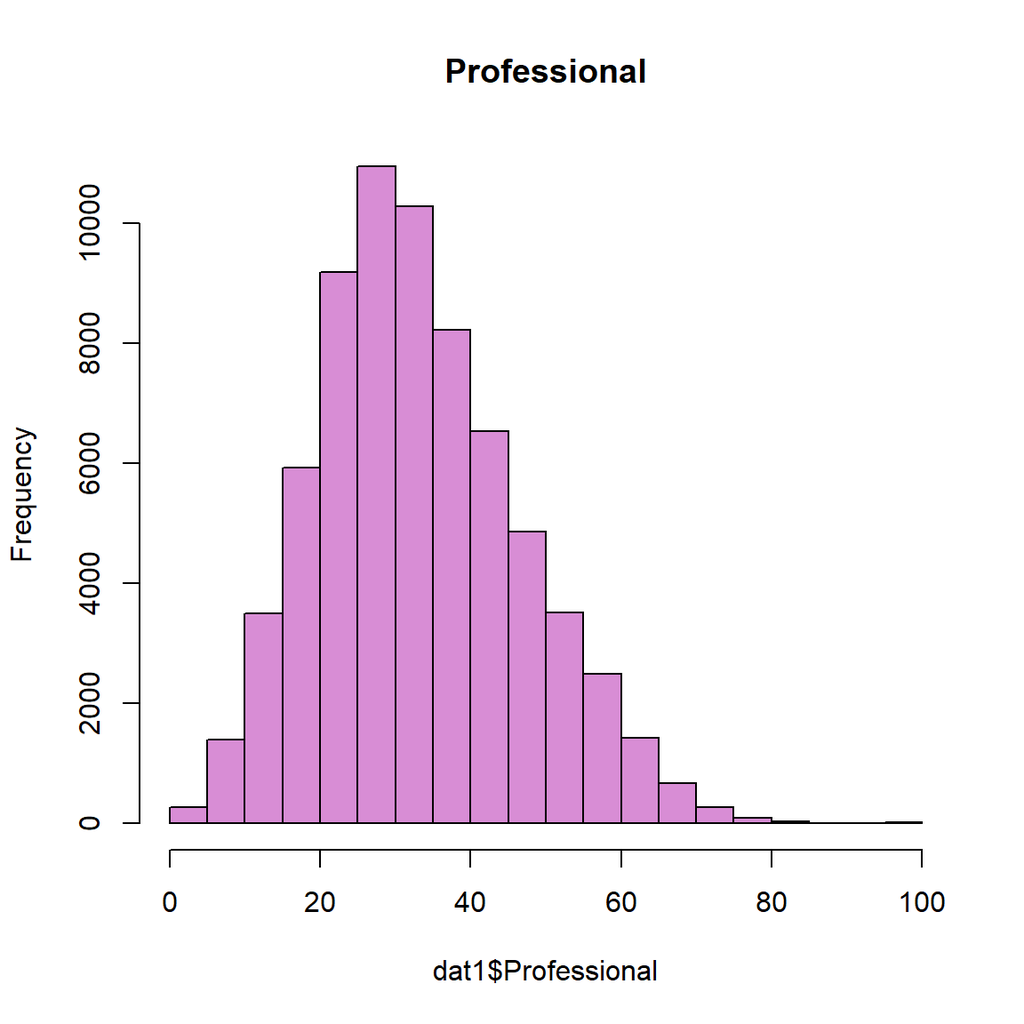

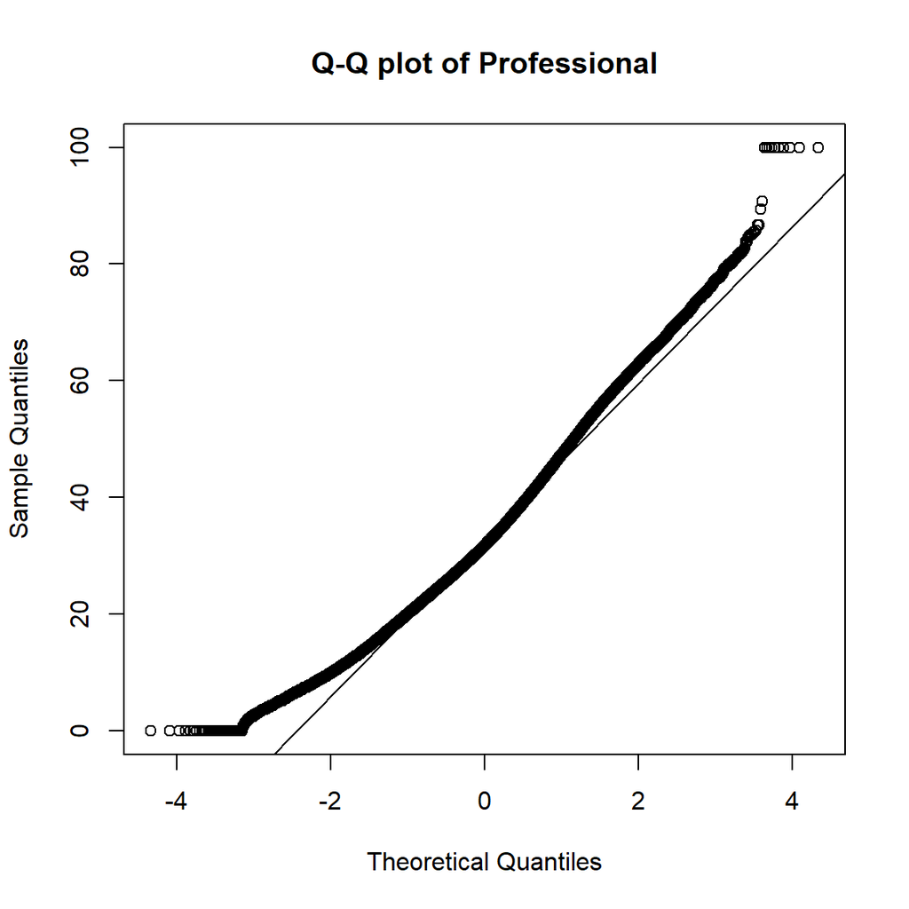

The only work variation that exhibited an increase in average income was professional work. Looking at the histograms of each of the variables it appeared that only the proportion of professionals was distributed normally. For professionals, the Q-Q plots affirmed the normality as the plot did not have the error terms straying far from the line with very small right and left tails. The same cannot be said for the other variables as each had an oversized right tail and a relatively small left tail. Overall the proportion of professionals appeared normally distributed while the other work variations did not.

The remaining variables of office and self-employed remained relatively stable across quartiles. The remaining six work variations were all skewed to the right.

### Ethnic variation

Finally the five ethnic variables (Native, White, Black, Hispanic, and Asian) were investigated.

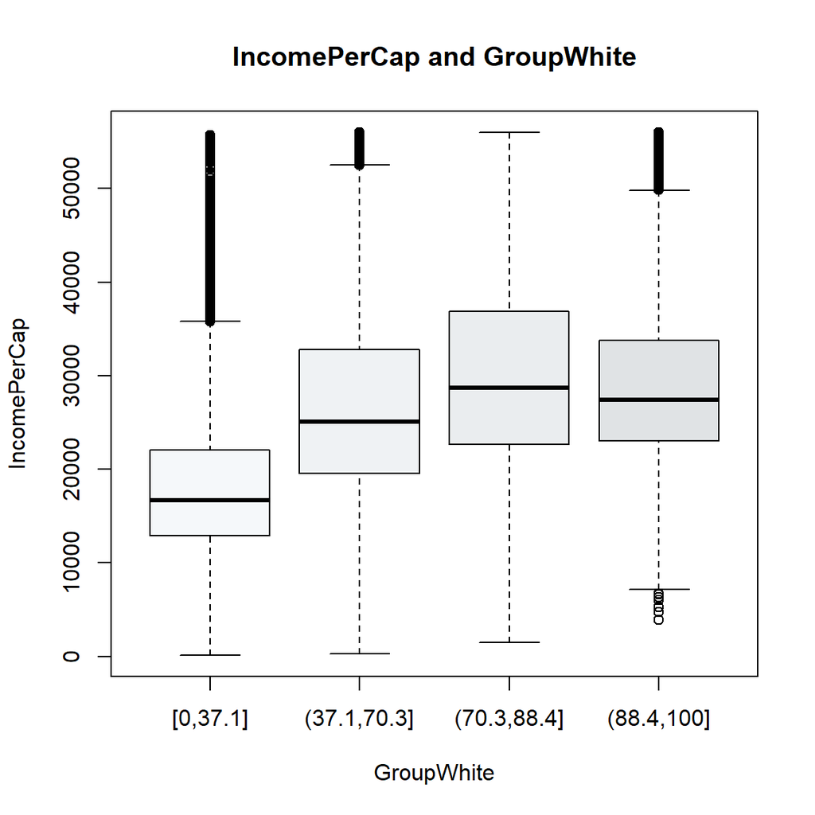

```
   Min. 1st Qu.  Median    Mean 3rd Qu.    Max.
   0.00   37.10   70.30   61.24   88.40  100.00
```

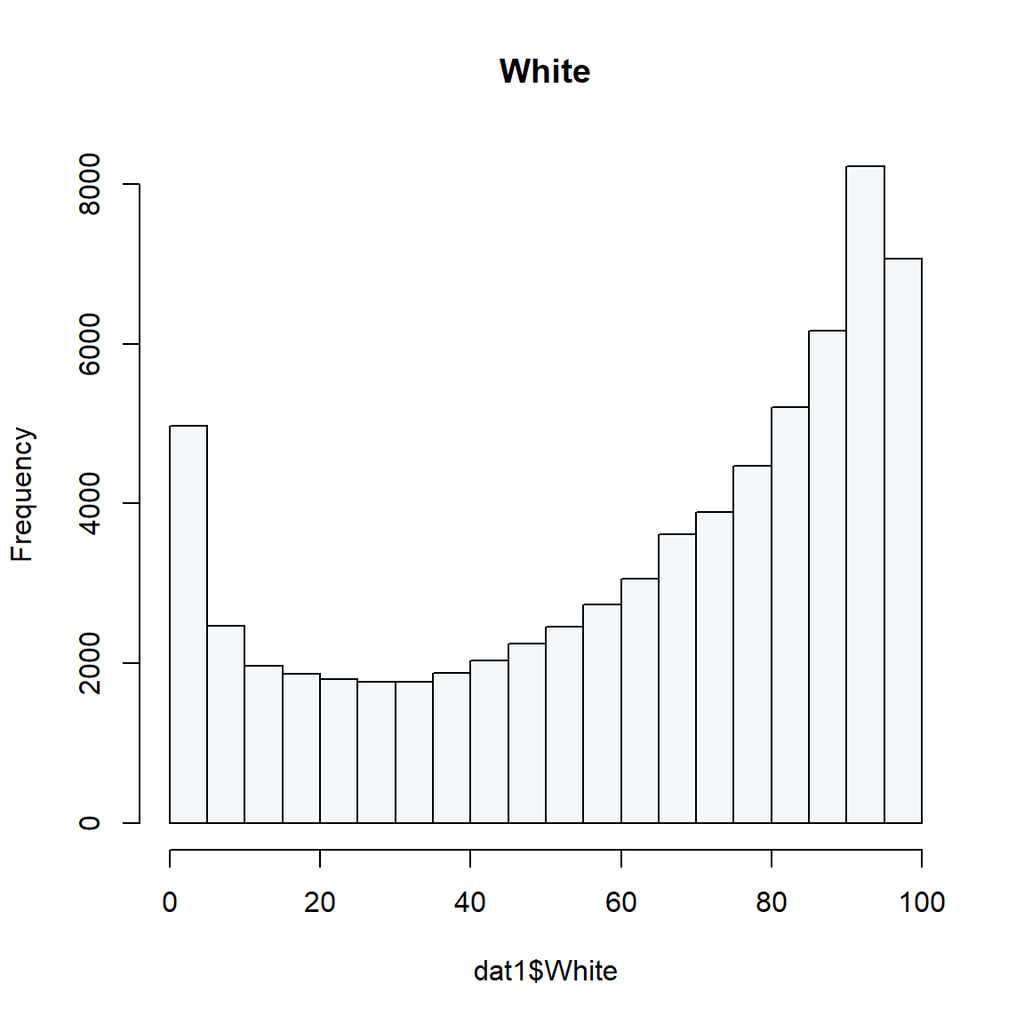

The boxplots for White showed an increase in average income between the first second and third quartiles but no change in the fourth. This indicates that census tracts with a greater proportion of white residents tend to have greater income.

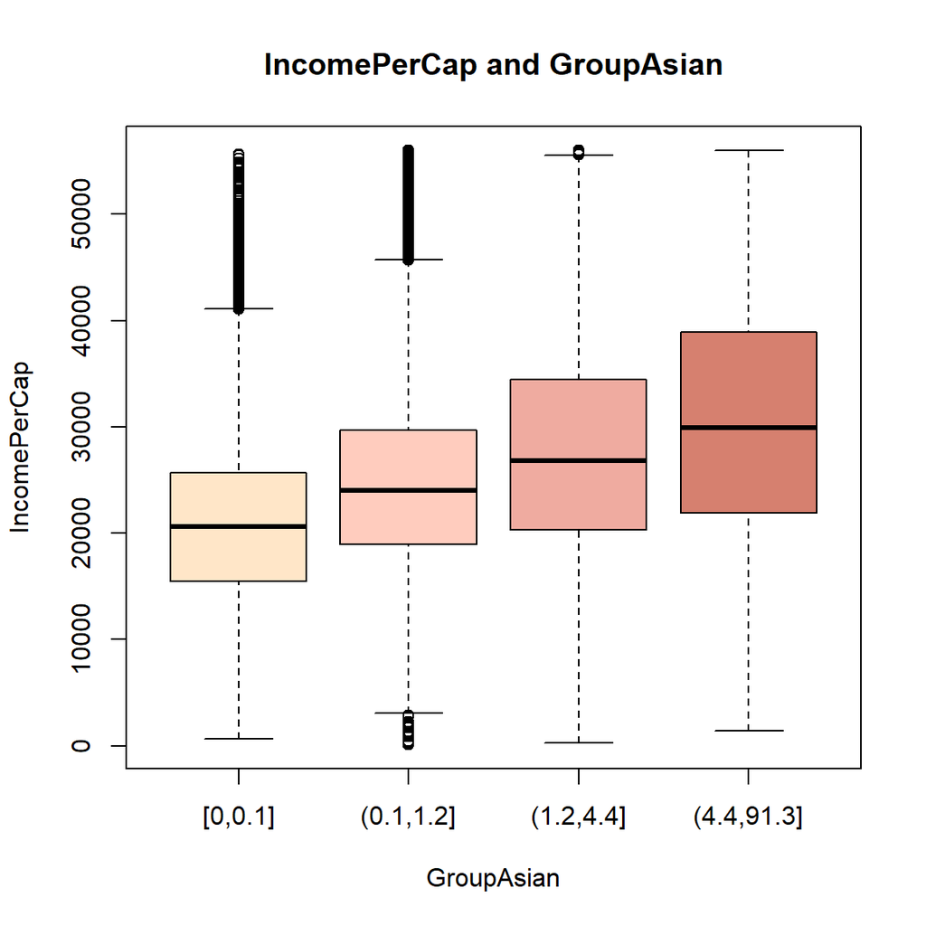

```
   Min. 1st Qu.  Median    Mean 3rd Qu.    Max.
  0.000   0.100   1.200   4.347   4.400  91.300
```

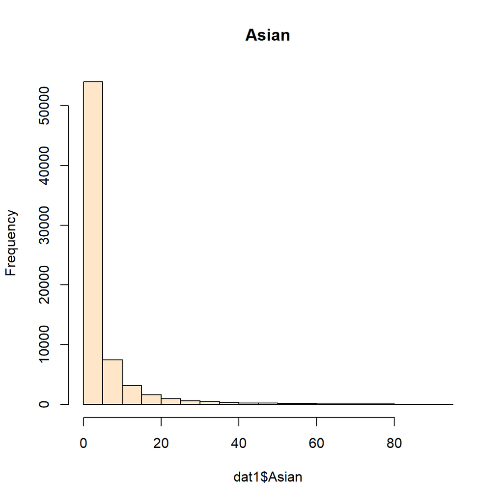

The boxplot for Asian showed an increase from the first through the fourth quartile.

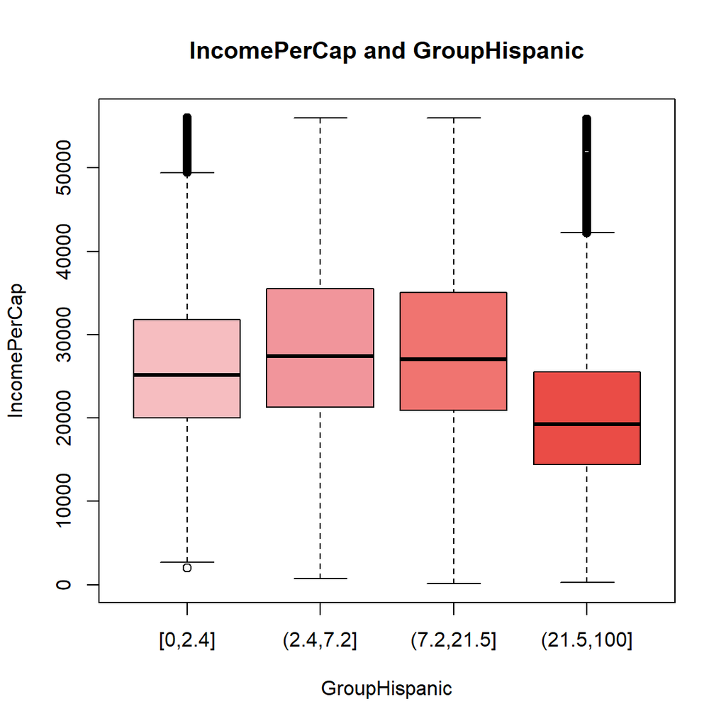

```
   Min. 1st Qu.  Median    Mean 3rd Qu.    Max.
   0.00    2.40    7.20   17.36   21.50  100.00
```

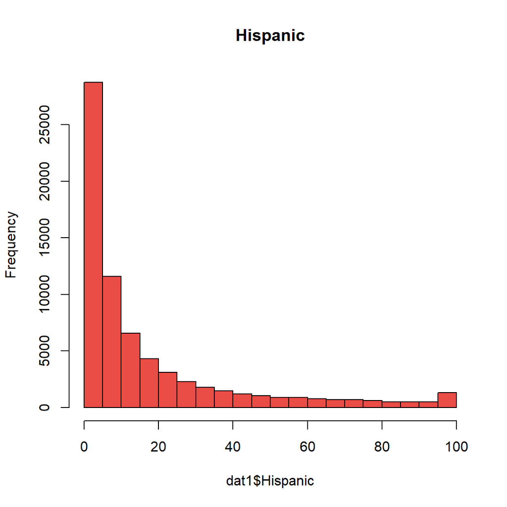

The boxplots for Hispanic slightly increased between the first and second quartile but did not change for the third quartile. The fourth quantile for Hispanic decreased significantly.

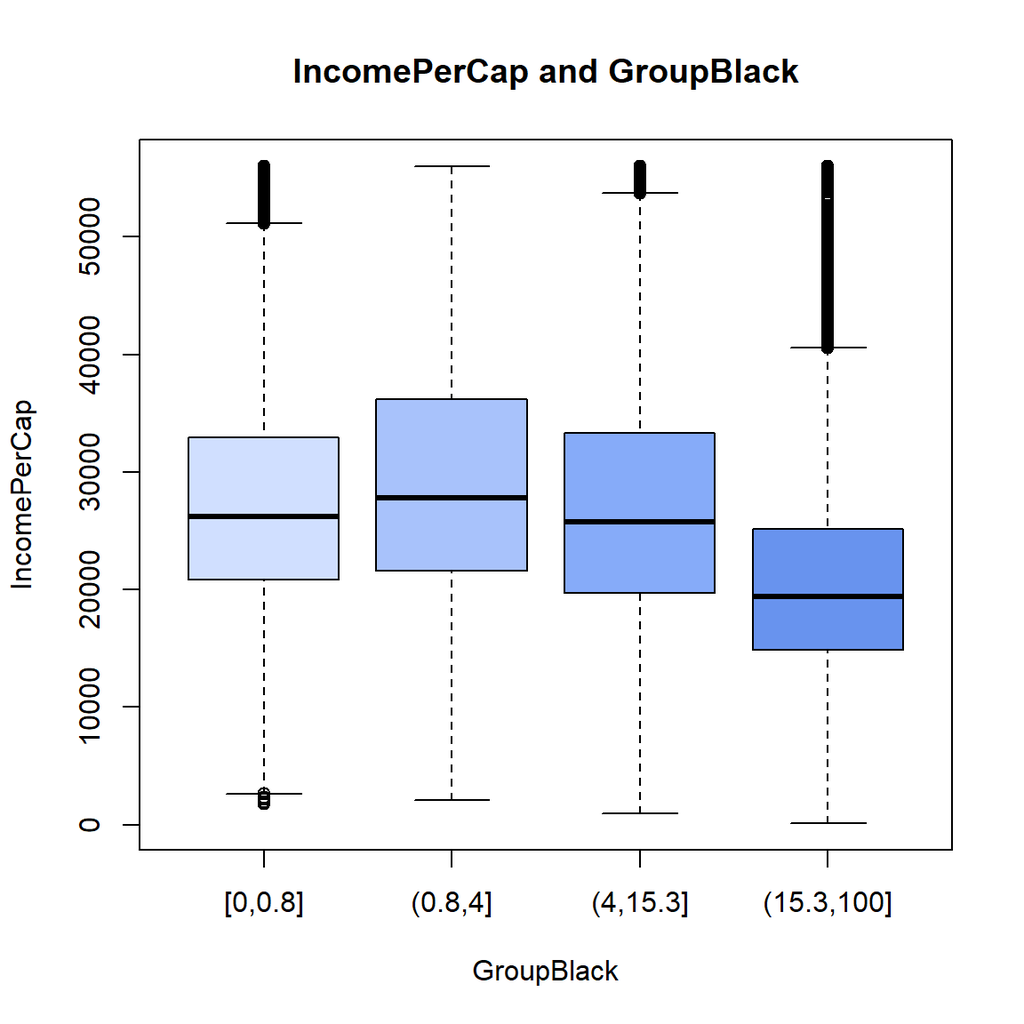

```
   Min. 1st Qu.  Median    Mean 3rd Qu.    Max.
   0.00    0.80    4.00   13.78   15.32  100.00
```

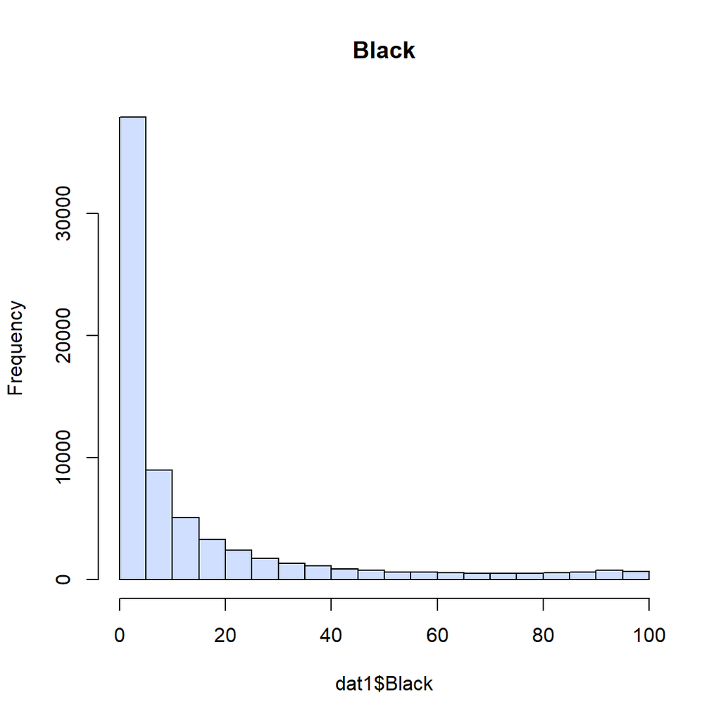

The boxplot for Black increased in average income between the first and second quartile. Then there was a decrease in average income from the second to the fourth quartiles. Overall, it appeared that average income did change based on concentration of ethnicities in a census tract.

The histogram for White was bimodal with the highest frequency at over 8,000. The histograms for the other four ethnicities were skewed to the right. Based on the histogram, it appeared that white had the highest responses followed by Hispanic, Black, Asian, and Native.

```
    Min.  1st Qu.   Median     Mean  3rd Qu.     Max.
  0.0000   0.0000   0.0000   0.7567   0.4000 100.0000
```

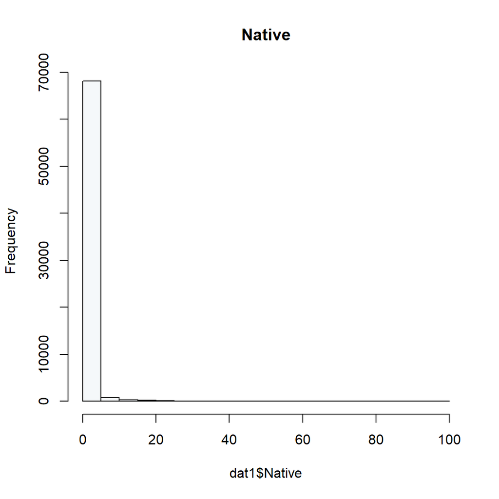

Also, there were not enough non-zero responses from the Native ethnicity to construct a meaningful boxplot. For this reason the Native variable was excluded from further analysis.

Altogether, based on the assessment of the boxplots, histograms, and Q-Q plots, none of the ethnicities appear normally distributed.

## Correlation Matrix

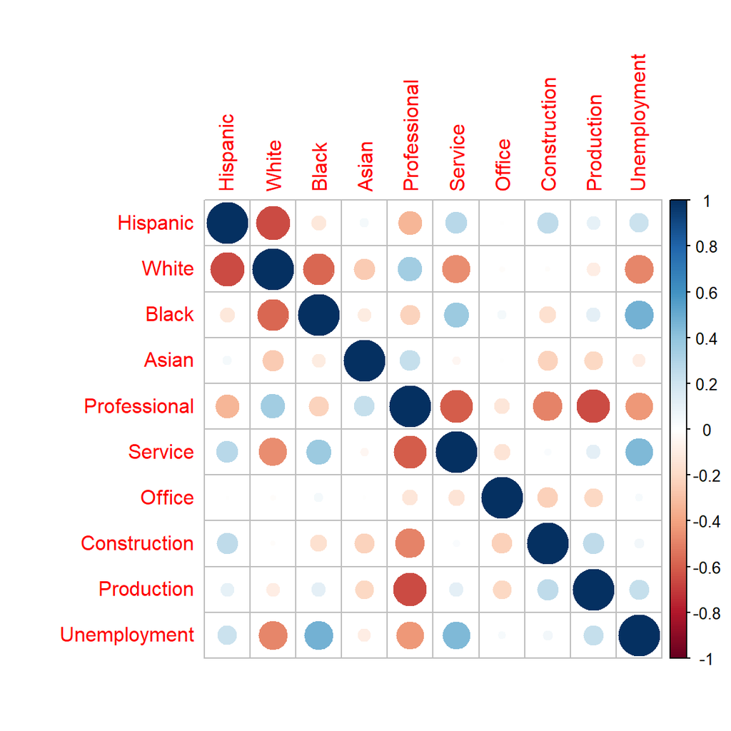

## Models: Why perform both clustering and prediction?

Throughout this report, both clustering models and prediction models were performed. Clustering models, such as PCA and K-means, are unsupervised learning methods. The objective was to find patterns in the data that help understand the relationship and closeness of ethnicity and work variables, and consequently subgrouping the dataset based on those patterns. Overall, it is important to use supervised and unserpervised models as it helps create a better holistic understanding of the data. In this study, the initial purpose was to understand income per capita. However, there are multiple independent variables that, according to this EDA, could be heavily correlated. Therefore, a clustering analysis could help us understand these relationship and make better conclusions about the reality of income in the U.S.

On the other hand, prediction models, such as KNN classification and regressions, are supervised learning whose main purpose is to understand the behaviour of a dependent variable. As shown in the EDA, the analysis included 10 independent variables and a single dependent variable: income per capita. Then, running classification and regression models was indispensable in this analysis.

# PCA

The purpose of Principle Component Analysis (PCA) and Principle Component Regression (PCR) is to decrease the number of variables while accounting for collinearity and therefore seemed suited to this dataset. Within this dataset there were 10 variables to explain IncomePerCap. However, the correlation matrix showed notable correlation between some of the predictor variables. For example, Professional had notable correlations with Service, Construction, Production and Unemployment, White had notable correlations with Hispanic and Black, etc. From this inital overview of the correlation matrix, the prospect of PCA seemed suitable and was continued.

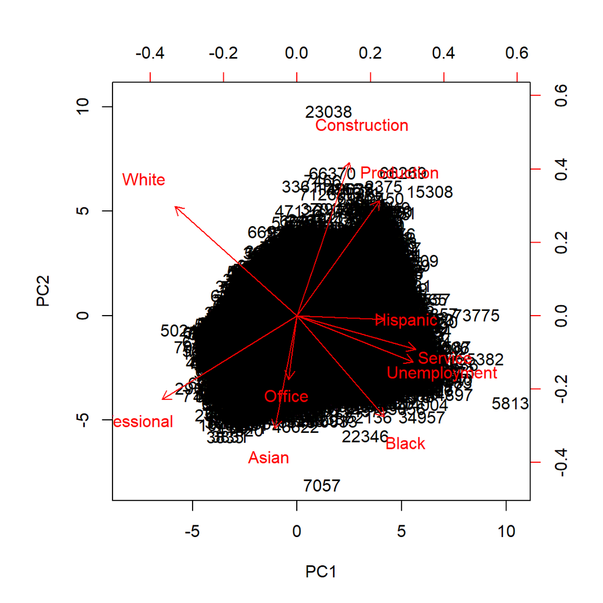

```
Importance of components:
                          PC1    PC2    PC3    PC4     PC5     PC6     PC7
Standard deviation     1.7878 1.3389 1.1653 1.0355 0.88819 0.82267 0.76933
Proportion of Variance 0.3196 0.1792 0.1358 0.1072 0.07889 0.06768 0.05919
Cumulative Proportion  0.3196 0.4989 0.6347 0.7419 0.82078 0.88845 0.94764
                           PC8     PC9     PC10
Standard deviation     0.71304 0.12303 0.003342
Proportion of Variance 0.05084 0.00151 0.000000
Cumulative Proportion  0.99849 1.00000 1.000000
```

The breakdown of the variation explained by each component showed that just over 60% of the variation was accounted for within the first three components. However, except for the first component, the change in the amount of variation explained in each consecutive component was similar. This was further illustrated by the following graph.

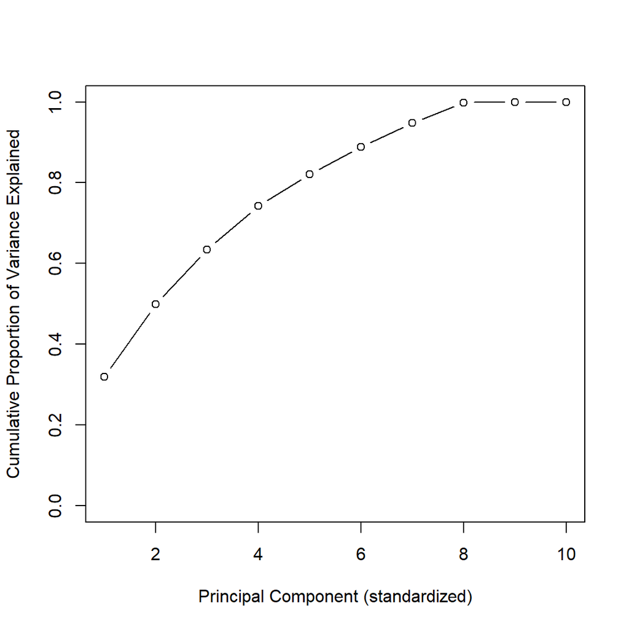

```
Call:
lm(formula = IncomePerCap ~ ., data = pcadata_pcr_rot)

Residuals:
   Min     1Q Median     3Q    Max
-57889  -3154   -136   3093  39355

Coefficients:
            Estimate Std. Error  t value Pr(>|t|)
(Intercept) 26167.82      20.93 1250.463  < 2e-16 ***
PC1         -4585.05      11.71 -391.701  < 2e-16 ***
PC2         -1454.29      15.63  -93.043  < 2e-16 ***
PC3           604.54      17.96   33.664  < 2e-16 ***
PC4           994.55      20.21   49.214  < 2e-16 ***
PC5          -878.20      23.56  -37.274  < 2e-16 ***
PC6          1377.18      25.44   54.140  < 2e-16 ***
PC7          -205.74      27.20   -7.564 3.96e-14 ***
PC8          -196.99      29.35   -6.712 1.93e-11 ***
PC9          3301.06     170.10   19.407  < 2e-16 ***
PC10        -3519.28    6262.21   -0.562    0.574
---
Signif. codes:  0 '***' 0.001 '**' 0.01 '*' 0.05 '.' 0.1 ' ' 1

Residual standard error: 5519 on 69556 degrees of freedom
Multiple R-squared:  0.7102,    Adjusted R-squared:  0.7101
F-statistic: 1.704e+04 on 10 and 69556 DF,  p-value: < 2.2e-16
```

A full principle component regression was performed, and all except the last component were deemed significant. It was also notable that this regression explained 71.01% of the variance in the dataset according the the adjusted R-Squared. The strongest variable was of course PC1 with a t-value with a magnitude by far larger than the rest of the variables.

```
Call:
lm(formula = IncomePerCap ~ PC1, data = pcadata_pcr_rot)

Residuals:
   Min     1Q Median     3Q    Max
-42965  -4026   -442   3546  36606

Coefficients:
            Estimate Std. Error t value Pr(>|t|)
(Intercept) 26167.82      23.34  1121.0   <2e-16 ***
PC1         -4585.05      13.06  -351.1   <2e-16 ***
---
Signif. codes:  0 '***' 0.001 '**' 0.01 '*' 0.05 '.' 0.1 ' ' 1

Residual standard error: 6157 on 69565 degrees of freedom
Multiple R-squared:  0.6393,    Adjusted R-squared:  0.6393
F-statistic: 1.233e+05 on 1 and 69565 DF,  p-value: < 2.2e-16
```

The results of this regression on just PC1 corroborated that the Adjusted R-Squared is smaller, at a value of 63.93%. The tradeoff between parsimony and description of these two potential models made the choice of model unclear. Assuming the more explanatory model, which accounted for the number of components included by adjusted R-Squared, was chosen, only one component would be removed. This was not an effective parsing down of variables. However, there would be low bias since only one component was dropped.

# K- Means

K-means is an unsupervised learning algorithm. The goal of this program is to find groups or clusters of data in order to identify certain patterns.

```
List of 9
 $ cluster     : Named int [1:69567] 2 2 2 2 2 1 2 1 2 2 ...
  ..- attr(*, "names")= chr [1:69567] "1" "2" "3" "4" ...
 $ centers     : num [1:2, 1:11] -0.329 0.174 0.42 -0.222 -0.32 ...
  ..- attr(*, "dimnames")=List of 2
  .. ..$ : chr [1:2] "1" "2"
  .. ..$ : chr [1:11] "Hispanic" "White" "Black" "Asian" ...
 $ totss       : num 7.31e+12
 $ withinss    : num [1:2] 1.15e+12 1.34e+12
 $ tot.withinss: num 2.5e+12
 $ betweenss   : num 4.81e+12
 $ size        : int [1:2] 24086 45481
 $ iter        : int 1
 $ ifault      : int 0
 - attr(*, "class")= chr "kmeans"
```

```
K-means clustering with 2 clusters of sizes 24086, 45481

Cluster means:
    Hispanic      White      Black      Asian Professional    Service
1 -0.3285506  0.4200874 -0.3199683  0.2372900    0.9282858 -0.6150829
2  0.1739950 -0.2224715  0.1694500 -0.1256649   -0.4916051  0.3257379
       Office Construction Production Unemployment IncomePerCap
1 -0.01890396   -0.4302842 -0.6556146   -0.5268802     37598.33
2  0.01001123    0.2278715  0.3472029    0.2790272     20114.40

Clustering vector:
 1  2  3  4  5  6  7  8  9 10 11 12 13 14 15 16 17 18 19 20 21 22 23 24 25 26
 2  2  2  2  2  1  2  1  2  2  2  2  2  2  2  1  2  2  1  1  2  2  1  2  2  2
27 28 29 30 31 32 33 34 35 36 37 38 39 40 41 42 43 45 46 47 48 49 50 51 52 53
 2  2  1  1  1  1  1  2  1  1  2  1  1  2  2  2  2  2  2  2  2  2  2  2  2  2
54 55 56 57 58 59 60 61 62 63 64 65 66 67 68 69 70 71 72 73 74 75 76
 2  2  2  2  2  2  2  2  2  2  2  2  2  2  2  2  2  2  2  2  2  2  2
 [ reached getOption("max.print") -- omitted 69492 entries ]

Within cluster sum of squares by cluster:
[1] 1.153649e+12 1.344211e+12
 (between_SS / total_SS =  65.8 %)

Available components:

[1] "cluster"      "centers"      "totss"        "withinss"     "tot.withinss"
[6] "betweenss"    "size"         "iter"         "ifault"
```

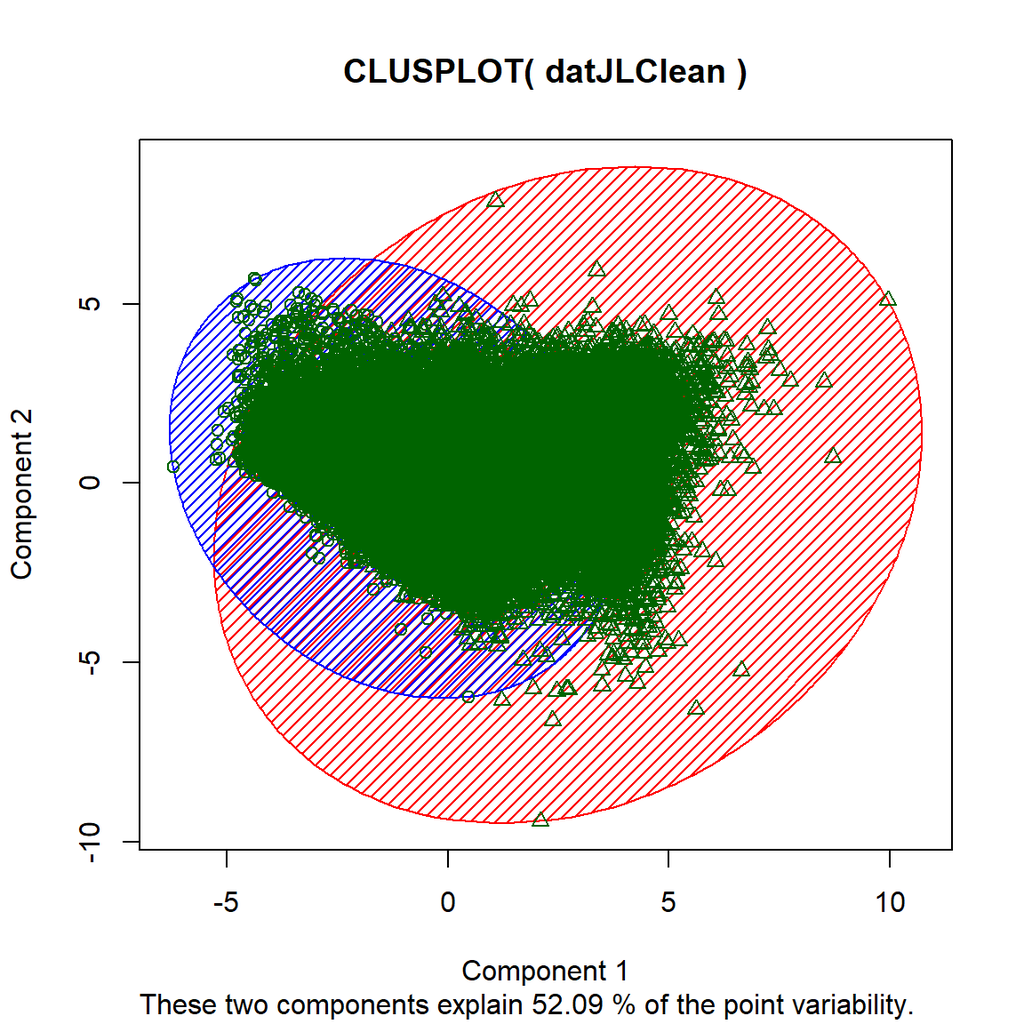

All of the values in the data set were normalized to make comparisons of the overall dataset on a similar scale. K-means was used for 2,3,4, and 10 clusters. On inspection of the clusters created from k=2, the cluster that had the highest IncomePerCap at 37598 had the highest cluster mean of professional at 0.928, White at 0.420 and Asian at 0.237. the cluster plot chart has all the 70,000 datapoints in green and the two different clusters in blue and red respectively.It appears that there is overlap of the clusters however this occurs as the plot takes all the different data points and plots them on a two dimensional graph. With only two clusters it captures about 65.8% of the cluster sum of squares.

```
List of 9
 $ cluster     : Named int [1:69567] 2 1 1 2 2 2 1 2 2 2 ...
  ..- attr(*, "names")= chr [1:69567] "1" "2" "3" "4" ...
 $ centers     : num [1:3, 1:11] 0.432 -0.24 -0.363 -0.575 0.34 ...
  ..- attr(*, "dimnames")=List of 2
  .. ..$ : chr [1:3] "1" "2" "3"
  .. ..$ : chr [1:11] "Hispanic" "White" "Black" "Asian" ...
 $ totss       : num 7.31e+12
 $ withinss    : num [1:3] 4.33e+11 3.94e+11 3.93e+11
 $ tot.withinss: num 1.22e+12
 $ betweenss   : num 6.09e+12
 $ size        : int [1:3] 27175 29638 12754
 $ iter        : int 2
 $ ifault      : int 0
 - attr(*, "class")= chr "kmeans"
```

```
K-means clustering with 3 clusters of sizes 27175, 29638, 12754

Cluster means:
    Hispanic      White      Black       Asian Professional    Service
1  0.4318377 -0.5751979  0.3952287 -0.15378102   -0.7689991  0.6127621
2 -0.2397814  0.3399978 -0.2076592 -0.02410908    0.1329131 -0.2111302
3 -0.3629095  0.4354829 -0.3595529  0.38368702    1.3296436 -0.8149861
       Office Construction  Production Unemployment IncomePerCap
1 -0.02605785    0.2974405  0.51204618    0.6194822     16576.79
2  0.07327428    0.0108065 -0.07894429   -0.3101802     27821.96
3 -0.11475466   -0.6588701 -0.90756657   -0.5991303     42759.54

Clustering vector:
 1  2  3  4  5  6  7  8  9 10 11 12 13 14 15 16 17 18 19 20 21 22 23 24 25 26
 2  1  1  2  2  2  1  2  2  2  2  1  1  1  2  2  2  1  3  3  2  2  2  1  2  2
27 28 29 30 31 32 33 34 35 36 37 38 39 40 41 42 43 45 46 47 48 49 50 51 52 53
 1  1  2  2  3  2  3  1  3  3  2  2  2  2  1  1  2  1  1  1  1  1  1  1  1  1
54 55 56 57 58 59 60 61 62 63 64 65 66 67 68 69 70 71 72 73 74 75 76
 1  1  2  1  1  1  1  1  1  1  1  2  1  1  1  1  1  2  1  1  1  1  1
 [ reached getOption("max.print") -- omitted 69492 entries ]

Within cluster sum of squares by cluster:
[1] 433025278355 393691127581 392888818743
 (between_SS / total_SS =  83.3 %)

Available components:

[1] "cluster"      "centers"      "totss"        "withinss"     "tot.withinss"
[6] "betweenss"    "size"         "iter"         "ifault"
```

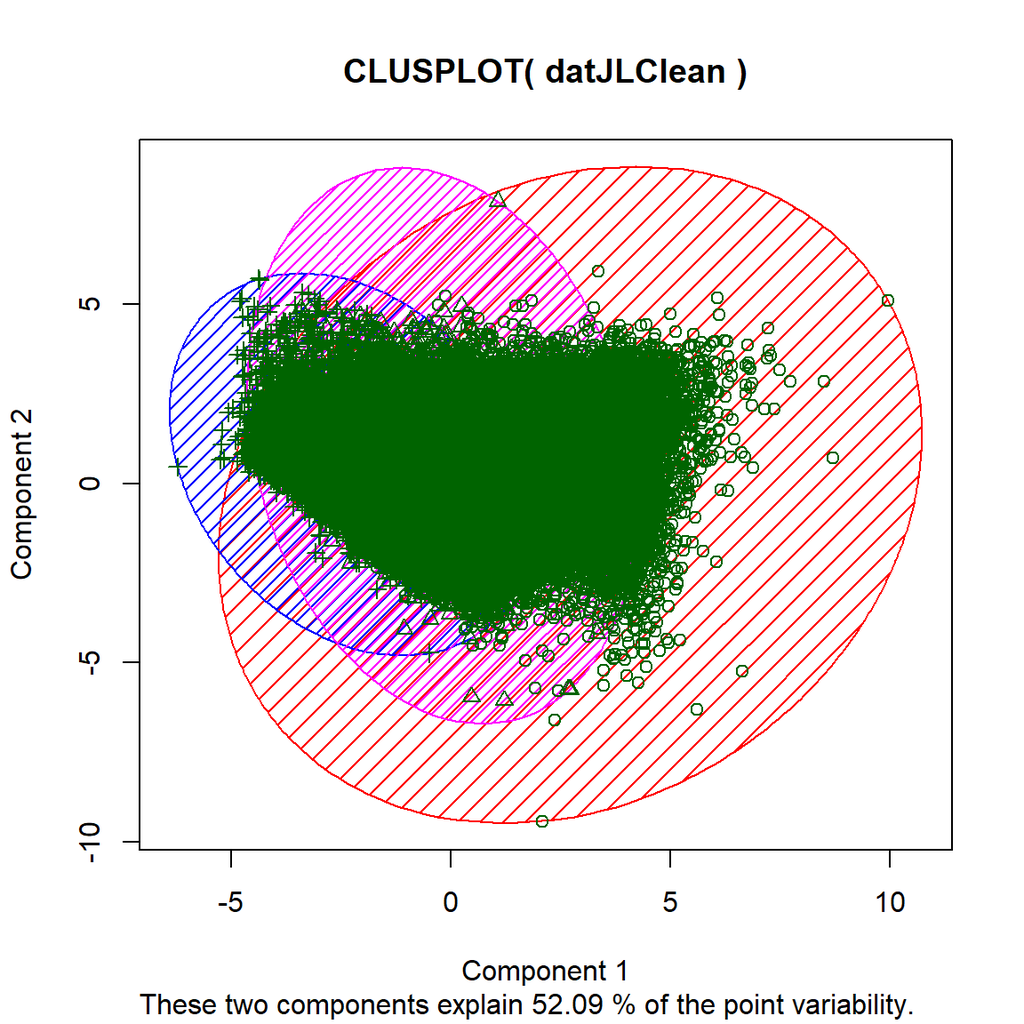

Further inspection was constructed for a model with k =3. The cluster with the highest IncomePerCap was found to be cluster three at 42760. this cluster also had the highest cluster mean for Professional at 1.330 and Asian at 0.3837. The first cluster which had a IncomePerCap cluster mean of 16577 had the highest uneployment cluster average at 0.619. the cluster plot has three distinct clusters portrayed and the overlap makes it a little difficult to see which cluster is which. With only three clusters, 83.3% of the data is captured which is a drastric improvement from only two clusters.

```
List of 9
 $ cluster     : Named int [1:69567] 4 2 4 4 4 1 4 1 4 4 ...
  ..- attr(*, "names")= chr [1:69567] "1" "2" "3" "4" ...
 $ centers     : num [1:4, 1:11] -0.302 0.668 -0.374 -0.132 0.407 ...
  ..- attr(*, "dimnames")=List of 2
  .. ..$ : chr [1:4] "1" "2" "3" "4"
  .. ..$ : chr [1:11] "Hispanic" "White" "Black" "Asian" ...
 $ totss       : num 7.31e+12
 $ withinss    : num [1:4] 1.76e+11 1.92e+11 1.73e+11 1.75e+11
 $ tot.withinss: num 7.15e+11
 $ betweenss   : num 6.6e+12
 $ size        : int [1:4] 17574 17698 8266 26029
 $ iter        : int 2
 $ ifault      : int 0
 - attr(*, "class")= chr "kmeans"
```

```
K-means clustering with 4 clusters of sizes 17574, 17698, 8266, 26029

Cluster means:
    Hispanic      White       Black      Asian Professional     Service
1 -0.3016974  0.4066104 -0.28173021  0.1074823    0.5711741 -0.43512866
2  0.6680011 -0.8809881  0.57590840 -0.1651807   -0.9293827  0.83254425
3 -0.3738848  0.4389987 -0.37976189  0.4559152    1.5331982 -0.92442949
4 -0.1317654  0.1850702 -0.08076331 -0.1050413   -0.2406168  0.02128076
       Office Construction Production Unemployment IncomePerCap
1  0.06629532   -0.2290380 -0.4319137  -0.46098899     32840.09
2 -0.05484069    0.3137655  0.5749681   0.89883620     14433.73
3 -0.17952039   -0.7693828 -1.0184110  -0.62970642     45780.77
4  0.04953752    0.1856318  0.2240905  -0.09992813     23412.84

Clustering vector:
 1  2  3  4  5  6  7  8  9 10 11 12 13 14 15 16 17 18 19 20 21 22 23 24 25 26
 4  2  4  4  4  1  4  1  4  4  4  4  4  2  4  1  4  2  1  1  4  4  1  2  4  4
27 28 29 30 31 32 33 34 35 36 37 38 39 40 41 42 43 45 46 47 48 49 50 51 52 53
 2  4  1  1  3  1  1  4  1  3  4  1  1  4  4  4  4  4  2  2  2  2  2  4  4  2
54 55 56 57 58 59 60 61 62 63 64 65 66 67 68 69 70 71 72 73 74 75 76
 2  4  4  2  4  4  4  2  2  2  4  4  4  2  2  4  4  4  2  4  2  4  4
 [ reached getOption("max.print") -- omitted 69492 entries ]

Within cluster sum of squares by cluster:
[1] 175536566241 191571930523 172553341760 175374034150
 (between_SS / total_SS =  90.2 %)

Available components:

[1] "cluster"      "centers"      "totss"        "withinss"     "tot.withinss"
[6] "betweenss"    "size"         "iter"         "ifault"
```

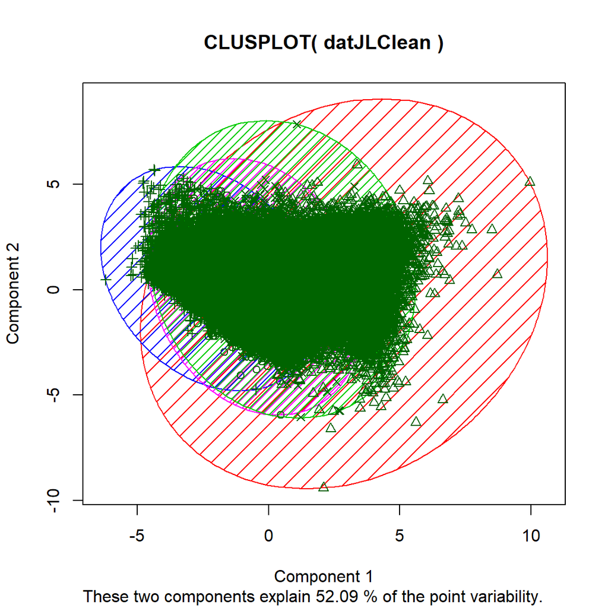

```
List of 9
 $ cluster     : Named int [1:69567] 1 8 10 1 5 5 10 6 1 1 ...
  ..- attr(*, "names")= chr [1:69567] "1" "2" "3" "4" ...
 $ centers     : num [1:10, 1:11] -0.219 1.288 -0.361 -0.401 -0.269 ...
  ..- attr(*, "dimnames")=List of 2
  .. ..$ : chr [1:10] "1" "2" "3" "4" ...
  .. ..$ : chr [1:11] "Hispanic" "White" "Black" "Asian" ...
 $ totss       : num 7.31e+12
 $ withinss    : num [1:10] 1.12e+10 1.74e+10 1.39e+10 1.27e+10 1.15e+10 ...
 $ tot.withinss: num 1.28e+11
 $ betweenss   : num 7.18e+12
 $ size        : int [1:10] 10068 3865 3958 2488 8688 6934 7565 9957 5277 10767
 $ iter        : int 2
 $ ifault      : int 0
 - attr(*, "class")= chr "kmeans"
```

```
K-means clustering with 10 clusters of sizes 10068, 3865, 3958, 2488, 8688, 6934, 7565, 9957, 5277, 10767

Cluster means:
      Hispanic      White       Black        Asian Professional     Service
1  -0.21894266  0.3228535 -0.18234201 -0.087339706  -0.06461379 -0.11255017
2   1.28797955 -1.3954285  0.66203610 -0.227681863  -1.10820404  1.22557254
3  -0.36067127  0.4329611 -0.37594612  0.433931771   1.47068572 -0.88529754
4  -0.40143948  0.4574908 -0.41624907  0.552865396   1.86667764 -1.11560010
5  -0.26857421  0.3814098 -0.24191694  0.001449229   0.27733630 -0.29947970
6  -0.31091712  0.4238401 -0.30526537  0.133107865   0.63900706 -0.46799362
         Office Construction  Production Unemployment IncomePerCap
1   0.066108550   0.12256875  0.08790777  -0.24792612    25611.181
2  -0.076791743   0.32434445  0.48520322   1.65358131     9524.098
3  -0.150092261  -0.74228280 -0.99238368  -0.63110451    44529.439
4  -0.323599903  -0.93488726 -1.16996086  -0.66198939    51688.147
5   0.094878659  -0.05916413 -0.20555508  -0.38831757    29399.124
6   0.075622849  -0.27384931 -0.49047224  -0.48675137    33668.105
 [ reached getOption("max.print") -- omitted 4 rows ]

Clustering vector:
 1  2  3  4  5  6  7  8  9 10 11 12 13 14 15 16 17 18 19 20 21 22 23 24 25 26
 1  8 10  1  5  5 10  6  1  1 10 10  8  8  1  5 10  7  6  9  1  1  5  8 10 10
27 28 29 30 31 32 33 34 35 36 37 38 39 40 41 42 43 45 46 47 48 49 50 51 52 53
 8  8  5  5  9  6  6 10  6  3 10  5  6 10  8  8  1  8  7  8  7  8  7  8 10  8
54 55 56 57 58 59 60 61 62 63 64 65 66 67 68 69 70 71 72 73 74 75 76
 8  8 10  7  8 10 10  8  8  8  8  1  8  7  8 10  8  1  8 10  7  8 10
 [ reached getOption("max.print") -- omitted 69492 entries ]

Within cluster sum of squares by cluster:
 [1] 11229084259 17370175686 13910959117 12674139695 11527257287 11975510243
 [7] 11954310598 12586251071 12940548385 11846270069
 (between_SS / total_SS =  98.2 %)

Available components:

[1] "cluster"      "centers"      "totss"        "withinss"     "tot.withinss"
[6] "betweenss"    "size"         "iter"         "ifault"
```

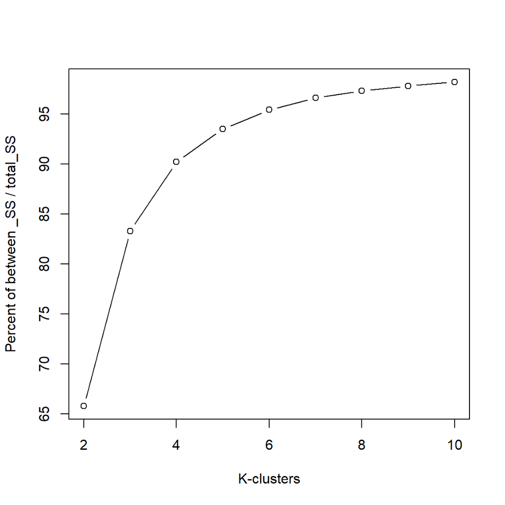

A final analysis was constructed for a model with k=4. The cluster with the highest IncomePerCap was found to be cluster three with 45781. this cluster had the hgihest Professional cluster average at 1.533 and the highest Asian cluster averge at 0.456. The cluster with the lowest IncomePerCap was cluster two at 14434. It had the highest unemployment cluster average at 0.8988. The cluster plot is difficult to interpret as the all of the datapoints were brought to a two dimensional scale and now there are four different clusters. With only four clusters, 90.2% of the data is captured which is a significant improvement from only two clusters. As the clusters increased from 4 to 10, the percentage captured did not increase drastically. For example when k= 10, 98.2% of the data is captured. Therefore, a cluster of four would be sufficient

# KNN

## Preprocessing KNN

Besides prediction, classification was another method that was performed in order to understand income per capita of census tracts. Is it possible to classify future census tract’s income per capita based on the information given related to work and ethnic variations? To answer this question the dependent variable was transformed into a classifiable variable. In other words, income per capita, a numerical variable, was splitted into four categories: low, medium low, medium high, and high income per capita.

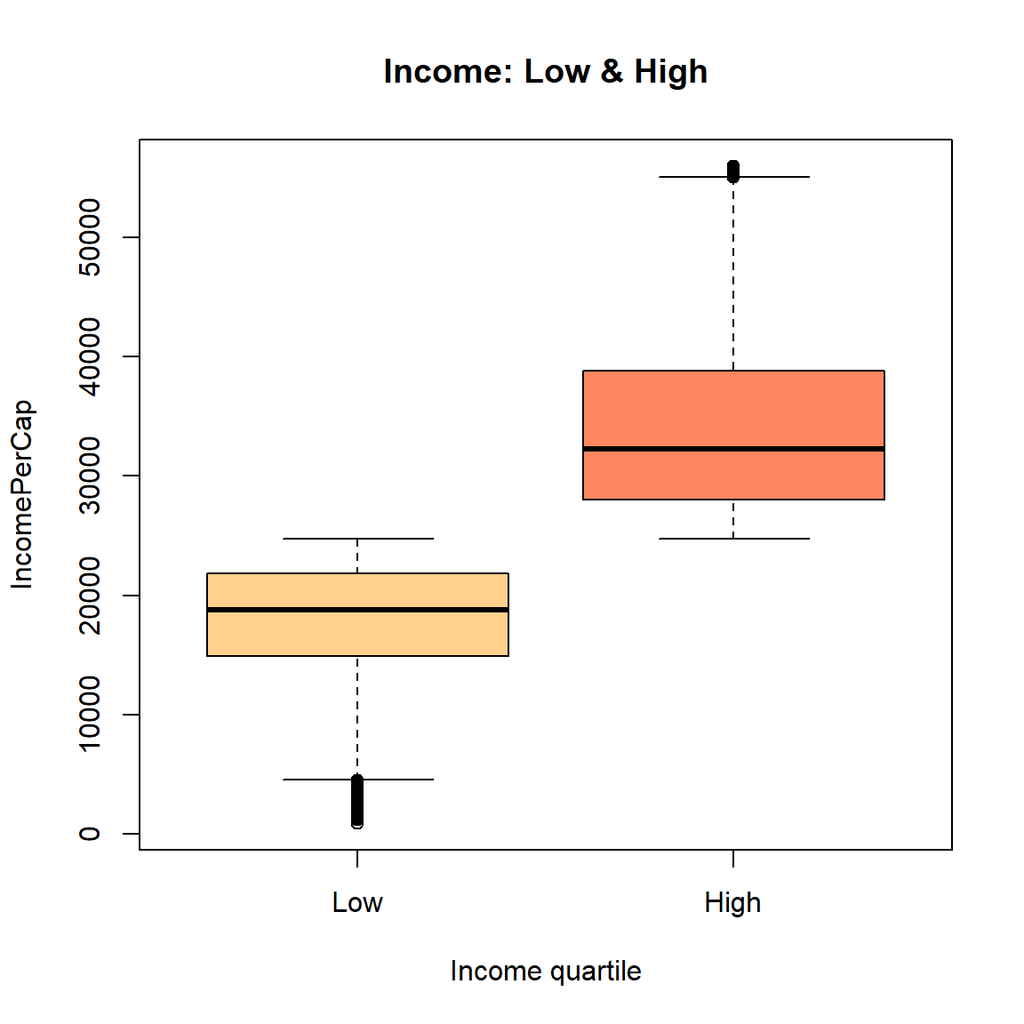

The function quant_groups was used. This separated the variable “income per capita” in quartiles and created a categorical variable with 4 categories. Each category has the same amount of observations (17418), and contains all census tracts ranging from the income per capita levels of each quartile. The new categorical variable included:

- Low: 0 - 18,000
- Mid-Low: 18,800 - 24,700
- Mid-High: 24,700 - 32,200
- High: 32,000 - 56,000

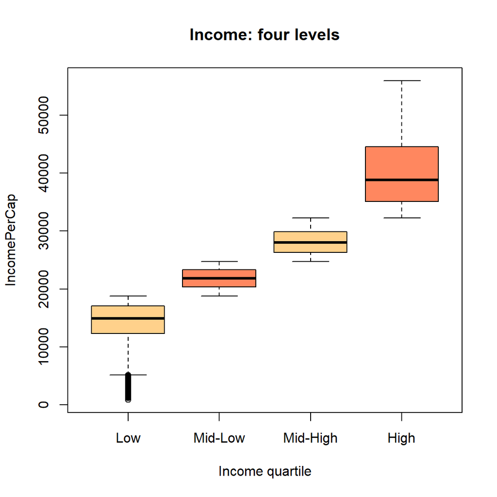

Separately, another variable was created from “income per capita” with only 2 categories. The purpose is to compare how classifying income per capita using 4 categories differs from classifying it using 2 categories. Therefore, a second categorical variable was created containing:

- Low: 0 - 24,700
- High: 24,700 - 56,000

Both new categorical variables were added to the dataset to perform the KNN classifier.

```
'data.frame':   69567 obs. of  12 variables:
 $ Hispanic    : num  0.9 0.8 0 10.5 0.7 13.1 3.8 1.3 1.4 0.4 ...
 $ White       : num  87.4 40.4 74.5 82.8 68.5 72.9 74.5 84 89.5 85.5 ...
 $ Black       : num  7.7 53.3 18.6 3.7 24.8 11.9 19.7 10.7 8.4 12.1 ...
 $ Asian       : num  0.6 2.3 1.4 0 3.8 0 0 0 0 0.3 ...
 $ Professional: num  34.7 22.3 31.4 27 49.6 24.2 19.5 42.8 31.5 29.3 ...
 $ Service     : num  17 24.7 24.9 20.8 14.2 17.5 29.6 10.7 17.5 13.7 ...
 $ Office      : num  21.3 21.5 22.1 27 18.2 35.4 25.3 34.2 26.1 17.7 ...
 $ Construction: num  11.9 9.4 9.2 8.7 2.1 7.9 10.1 5.5 7.8 11 ...
 $ Production  : num  15.2 22 12.4 16.4 15.8 14.9 15.5 6.8 17.1 28.3 ...
 $ Unemployment: num  5.4 13.3 6.2 10.8 4.2 10.9 11.4 8.2 8.7 7.2 ...
 $ ipc2        : Factor w/ 2 levels "Low","High": 2 1 1 1 2 2 1 2 1 1 ...
 $ ipc4        : Factor w/ 4 levels "Low","Mid-Low",..: 3 1 2 2 3 3 2 4 2 2 ...
```

The dataset that was used to perform the KNN contained “ipc2” and “ipc4” along with the independent variables used to classify income per capita.

## KNN 2 categories

### Selecting the correct “k”

The first KNN model performed tried to classify census tract’s income in two categories: Low or High. First, the chooseK() function was applied to determine the best KNN K value for the model.

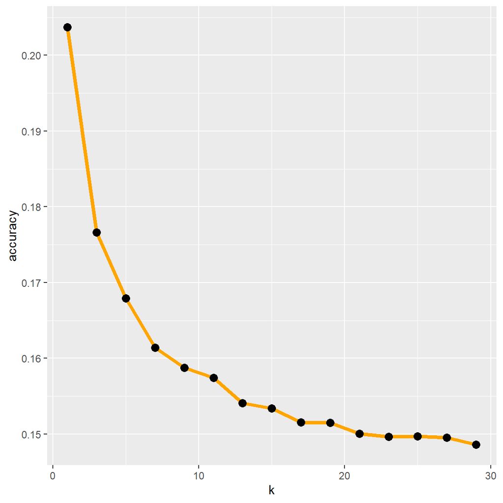

### Results

```
             dat_ipc2.testLabels
dat_pred_ipc2  Low High
         High 1940 9719
         Low  9492 1685
```

```
[1] 0.1587406
```

As shown in the confusion matrix, the model can classify the income level of a census tract based on their work and ethnic demographics with an accuracy of 84%. For the test set, that corresponded to 19,210 observations predicted successfully out of 22,836. However, this high accuracy score corresponded only to the classification of two categories: low and high.

The reality of income in the U.S. is much more complex than that. Therefore, it makes sense to perform another model trying to classify 4 categories instead.

## KNN 4 categories

### Selecting the correct “k”

The next KNN model tried to classify census tract’s income in four categories: Low, Mid-low, Mid-High and High.

```
 num [1:2, 1:15] 1 0.563 3 0.597 5 ...
```

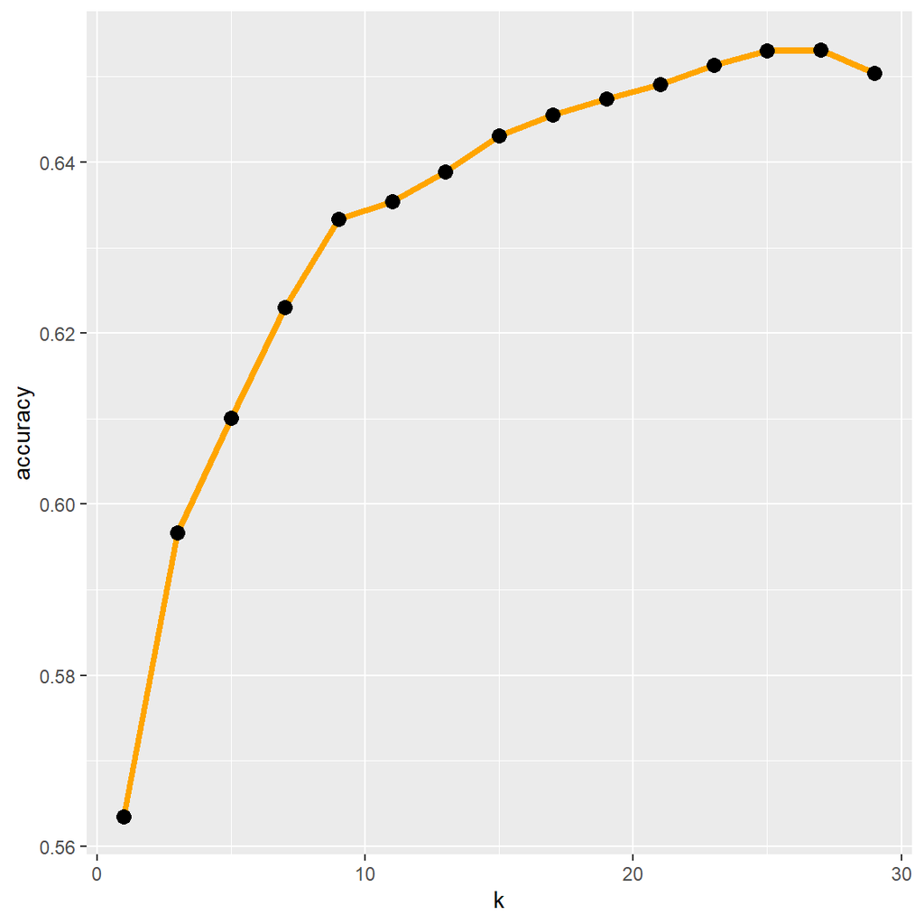

## Results

```
             dat_ipc4.testLabels
dat_pred_ipc4  Low Mid-Low Mid-High High
     Low      4120     982      165   19
     Mid-Low  1299    2996     1422  169
     Mid-High  238    1510     2923 1089
     High       66     221     1223 4394
```

```
[1] 0.6320284
```

In reality, income per capita is a numerical variable. So the classification exercise served only as a proxy to understand how census tracts can be classified based on their demographics, but is not by any means a completely reliable tool to predict income in the U.S.

# Linear Regression

## Basic Linear Regression

The predictive modeling began with a simple linear regression model. This allows for basic statements about how the variables of interest correlate with income, but won’t be an appropriate final model, since it does not allow for interactions between components which have already been shown to be inter-related. The process begins with an exhaustive search of our variables of interest.

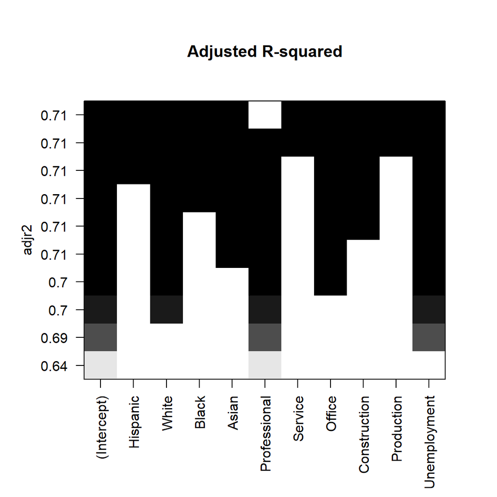

The exhaustive search indicates, by adjusted R-squared, that all variables except Professional should be included. Since there are few practical costs to expanding the model, the model with the highest adjusted value is appropriate. Note that Professional is excluded not because it is individually unhelpful, but because the set of work types sums to one, so one of them will always be dropped. Feature selection with BIC and Cp was also conducted, with similar results. For brevity, they are not included here.

```
Call:
lm(formula = IncomePerCap ~ . - Professional, data = datDisc)

Residuals:
   Min     1Q Median     3Q    Max
-57889  -3154   -136   3093  39362

Coefficients:
              Estimate Std. Error t value Pr(>|t|)
(Intercept)  51988.355    396.421  131.14   <2e-16 ***
Hispanic        41.671      3.749   11.11   <2e-16 ***
White           96.026      3.777   25.42   <2e-16 ***
Black           53.109      3.803   13.97   <2e-16 ***
Asian          128.931      4.808   26.82   <2e-16 ***
Service       -536.921      3.174 -169.15   <2e-16 ***
Office        -383.300      3.848  -99.62   <2e-16 ***
Construction  -444.860      4.003 -111.12   <2e-16 ***
Production    -533.878      3.054 -174.82   <2e-16 ***
Unemployment  -270.607      4.495  -60.20   <2e-16 ***
---
Signif. codes:  0 '***' 0.001 '**' 0.01 '*' 0.05 '.' 0.1 ' ' 1

Residual standard error: 5519 on 69557 degrees of freedom
  (105 observations deleted due to missingness)
Multiple R-squared:  0.7102,    Adjusted R-squared:  0.7101
F-statistic: 1.894e+04 on 9 and 69557 DF,  p-value: < 2.2e-16
```

```
    Hispanic        White        Black        Asian      Service       Office
   17.508348    31.446591    16.187328     3.948750     1.475878     1.153010
Construction   Production Unemployment
    1.291156     1.195779     1.621923
```

Above are the vif values for the simple linear regression. It is clear that there is a very high level of covariance among the ethnicity variables, since these variables sum to a value near one. The work variables face lower covariance only because the “professional” component from this model was removed.

# Logistic Regression

```
Call:
glm(formula = ipc2 ~ . - Professional, family = "binomial", data = datCap)

Deviance Residuals:
    Min       1Q   Median       3Q      Max
-4.8951  -0.4877  -0.0008   0.5058   3.6690

Coefficients:
              Estimate Std. Error z value Pr(>|z|)
(Intercept)   8.228716   0.274949  29.928  < 2e-16 ***
Hispanic      0.012636   0.002618   4.827 1.39e-06 ***
White         0.035635   0.002595  13.731  < 2e-16 ***
Black         0.016223   0.002660   6.099 1.06e-09 ***
Asian         0.050056   0.003198  15.652  < 2e-16 ***
Service      -0.178282   0.002240 -79.605  < 2e-16 ***
Office       -0.105012   0.002350 -44.693  < 2e-16 ***
Construction -0.134956   0.002513 -53.710  < 2e-16 ***
Production   -0.190392   0.002141 -88.937  < 2e-16 ***
Unemployment -0.141476   0.003131 -45.181  < 2e-16 ***
---
Signif. codes:  0 '***' 0.001 '**' 0.01 '*' 0.05 '.' 0.1 ' ' 1

(Dispersion parameter for binomial family taken to be 1)

    Null deviance: 96440  on 69566  degrees of freedom
Residual deviance: 48184  on 69557  degrees of freedom
AIC: 48204

Number of Fisher Scoring iterations: 6
```

Taking a logistic regression - analyzing how the variables predict whether a given census ract will fall within the upper half of the income distribution or the lower half - produced similar results. All of the same predictor variables remained significant, with the same signs and similar relative scales. It can now be seen more clearly, however, that a high proportion of asian and white citizens correlate with higher likelihood to end up within the upper end of the income distribution, while greater reliance on work in the production and service sectors lowers this likelihood.

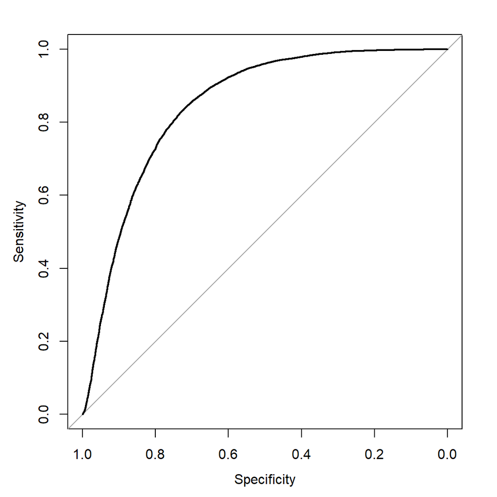

As a final check, the receiver operating characteristic curve for the generalized linear regression was constructed. The curve is quite full, with an AUC of 0.8448603. This indicates that the logistic model already quite efficiently predicts income.

# Ridge Regression

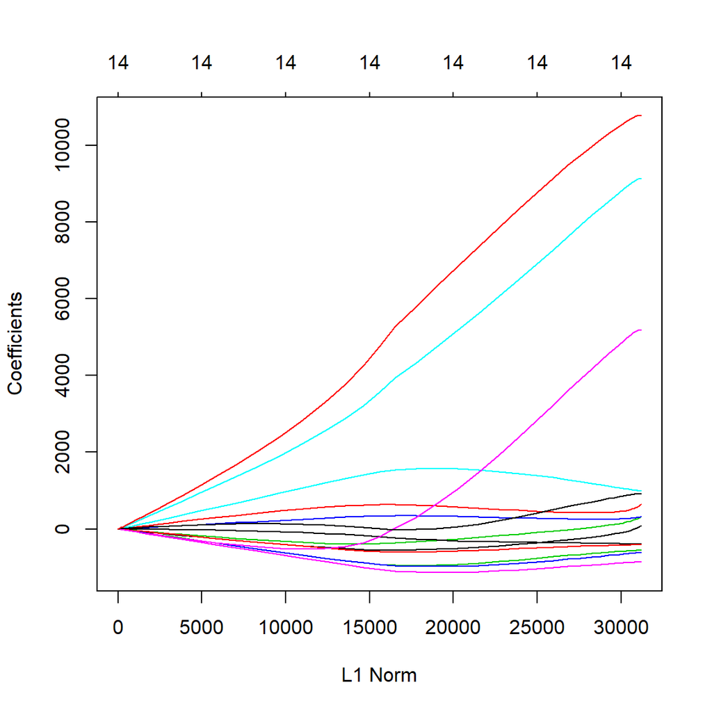

## Train and Test sets

To avoid introducing a bias in developing the Ridge and Lasso regression a train and test data set were introduced. To simulate a train and test set there was a random split into 50% for the train set.

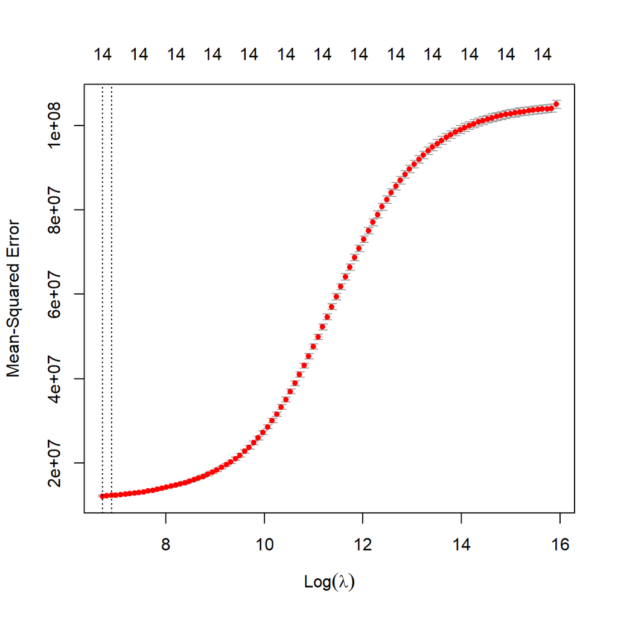

```
lowest lamda from CV:  824.8974
```

```
MSE for best Ridge lamda:  12154666
```

```
All the coefficients :
```

```
 (Intercept)     Hispanic        White        Black        Asian Professional
  19143.7093    -300.1618     436.8876     -34.8267     267.4880    1313.3468
     Service       Office Construction   Production Unemployment
   -988.9918    -358.9968    -465.5783    -707.8713    -806.0590
```

```
R-squared:
```

```
[1] 0.8843423
```

# Lasso Regression

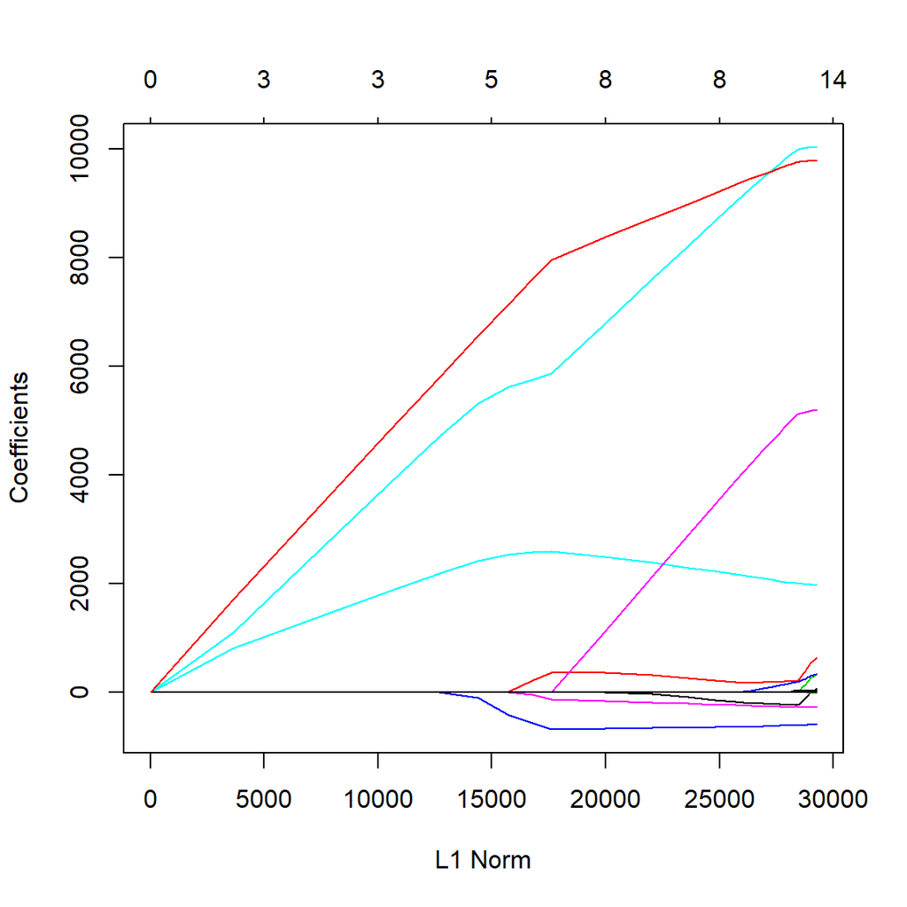

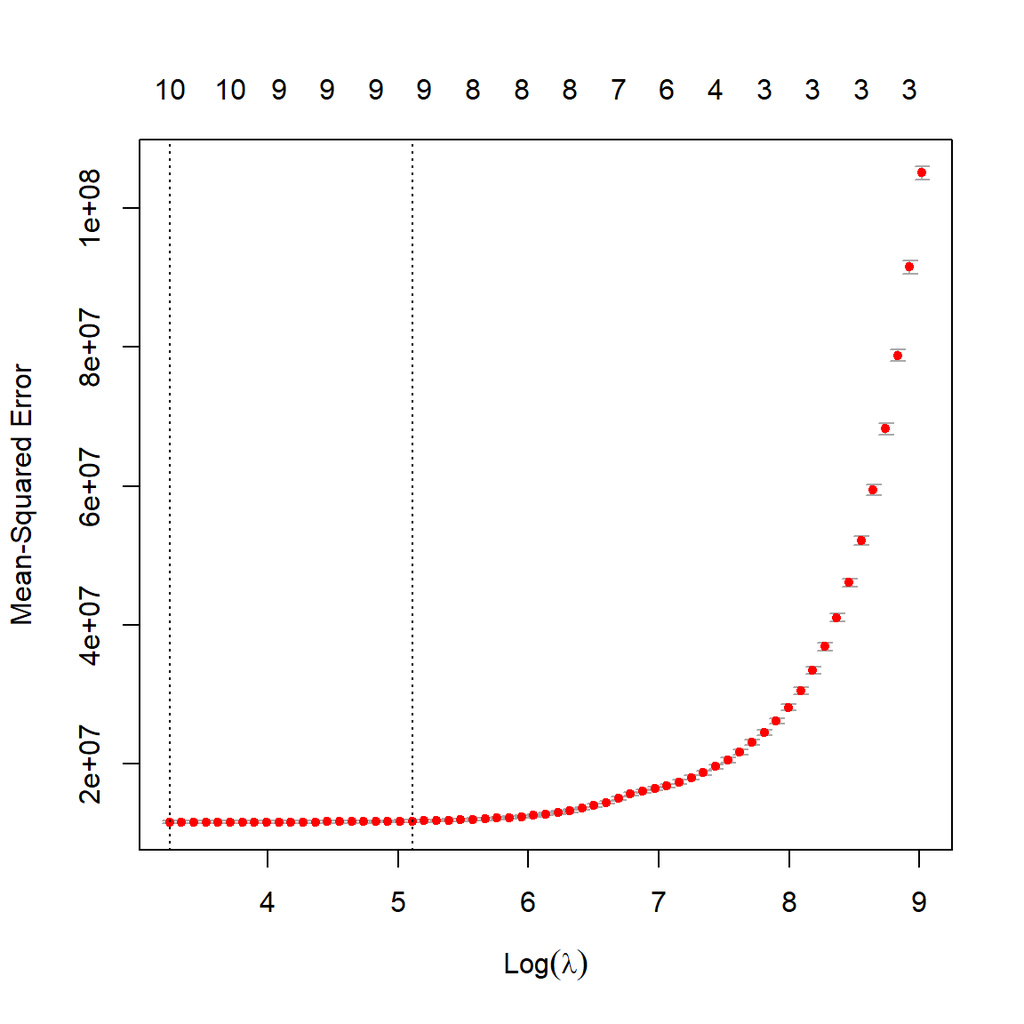

```
lowest lamda from CV:  25.78395
```

```
 MSE for best Lasso lamda:  11672982
```

```
All the coefficients :
```

```
 (Intercept)     Hispanic        White        Black        Asian Professional
17484.872000  -212.822777   219.903152     0.000000   165.286025  1987.274255
     Service       Office Construction   Production Unemployment
 -284.732831     8.180852     0.000000    -4.656966  -619.976123
```

```
The non-zero coefficients :
```

```
 (Intercept)     Hispanic        White        Asian Professional      Service
17484.872000  -212.822777   219.903152   165.286025  1987.274255  -284.732831
      Office   Production Unemployment
    8.180852    -4.656966  -619.976123
```

```
[1] 0.8889258
```

```
Call:
lm(formula = IncomePerCap ~ ., data = datJLClean)

Residuals:
     Min       1Q   Median       3Q      Max
-27748.0  -1894.5    -20.2   1770.9  18988.4

Coefficients: (1 not defined because of singularities)
             Estimate Std. Error  t value Pr(>|t|)
(Intercept)  17391.74      36.71  473.707  < 2e-16 ***
Hispanic       104.54      54.22    1.928   0.0539 .
White          669.66      72.93    9.183  < 2e-16 ***
Black          334.20      52.11    6.414 1.43e-10 ***
Asian          326.28      25.82   12.635  < 2e-16 ***
Professional  1077.33    2706.77    0.398   0.6906
Service       -814.52    1609.32   -0.506   0.6128
Office        -358.87    1173.52   -0.306   0.7598
Construction  -378.99    1193.57   -0.318   0.7508
Production    -515.94    1505.74   -0.343   0.7319
Unemployment  -616.00      17.07  -36.087  < 2e-16 ***
ipc2High     19892.01      62.25  319.559  < 2e-16 ***
ipc4Mid-Low   5181.26      42.82  120.998  < 2e-16 ***
ipc4Mid-High -9860.07      41.82 -235.757  < 2e-16 ***
ipc4High           NA         NA       NA       NA
---
Signif. codes:  0 '***' 0.001 '**' 0.01 '*' 0.05 '.' 0.1 ' ' 1

Residual standard error: 3412 on 69553 degrees of freedom
Multiple R-squared:  0.8893,    Adjusted R-squared:  0.8892
F-statistic: 4.296e+04 on 13 and 69553 DF,  p-value: < 2.2e-16
```

```
Call:
lm(formula = IncomePerCap ~ Hispanic + White + Black + Asian +
    Professional + Service + Office + Production + Unemployment,
    data = datJLClean)

Residuals:
   Min     1Q Median     3Q    Max
-57889  -3155   -139   3092  39315

Coefficients:
             Estimate Std. Error t value Pr(>|t|)
(Intercept)  26167.82      20.93 1250.46   <2e-16 ***
Hispanic       972.98      87.56   11.11   <2e-16 ***
White         2983.19     117.35   25.42   <2e-16 ***
Black         1175.89      84.20   13.97   <2e-16 ***
Asian         1115.17      41.58   26.82   <2e-16 ***
Professional  5991.86      53.93  111.11   <2e-16 ***
Service       -737.90      39.77  -18.55   <2e-16 ***
Office         359.14      28.63   12.54   <2e-16 ***
Production    -667.56      40.62  -16.44   <2e-16 ***
Unemployment -1604.14      26.65  -60.19   <2e-16 ***
---
Signif. codes:  0 '***' 0.001 '**' 0.01 '*' 0.05 '.' 0.1 ' ' 1

Residual standard error: 5519 on 69557 degrees of freedom
Multiple R-squared:  0.7102,    Adjusted R-squared:  0.7101
F-statistic: 1.894e+04 on 9 and 69557 DF,  p-value: < 2.2e-16
```

```
MSE for full model :
```

```
[1] 11638291
```

```
MSE for full model (w/o construction) :
```

```
[1] 30460435
```

# Conclusion

Overall, this analysis found that there are several models through which our independent variables reliably predict income in communities across the United States.

Ethnicity and work type proportions both have strong predictive power, with the latter having the most powerful effects. However, these variables suffer from being largely non-normal, with a rightward skew, and from having high internal correlations, both between and within the two categories.

K-means was utilized to see how the data would group together so clusters with different IncomePerCaps may have specific ethnicity or work variation cluster means. Clusters were constructed for k=2,3,4, and 10. Overall for larger income groups, it appears to have higher averages for Professional. Also, as more clusters were added, a greater percentage of data variation was explained. Four clusters became the optimal choice as it explained 90.2 % while 3 clusters explained 83.3% and 10 clusters explained 98.2%. There wasn’t much of an increase from 4 to 10 and just enough increase from 3 to 4.

KNN could work well as an exercise to classify future census tracts based on their demographics. It is a method that functions as a good aproximation to understand how census tracts can be classified. It is different from prediction or regression, since the amount of variation of the dependent variable is unknown while indepedent variables vary.

Altogether, these variables allowed the model to predict income per capita at the census tract level with high reliability, even with simple models (R-squared = 0.7101805); this is actually quite impressive given the simplicity of this data. For instance, it does not directly include any information about the age or education of the population. The categorical case was also considered, where half or quarter of the income distribution that each census tract will fall within was predicted. Again, an efficient simple model was easily constructed.

Moving forward, this analysis allows for several expansions. The first is to integrate new data, such as age and education status of census tract residents. Additionally, it may be valuable to consider state level differences between census tracts, which may indicate the effect of state laws and policies. In a similar vein, the repeated nature of this data set would allow for performing this analysis at multiple time slices, which would allow for models with causal elements. Finally, it is interesting if there are differences driven by geographic density, which can be estimated with just the currently accessible data.

# Bibliography

MuonNeutrino. (2015). US Census Demographic Data: Demographic and Economic Data for Tracts and Counties. UpToDate. Retrieved March 23, 2020, from https://www.kaggle.com/muonneutrino/us-census-demographic-dataD

U.S. Census Bureau (2019). “Annual Estimates of the Resident Population for the United States, Regions, States, and Puerto Rico: April 1, 2010 to July 1, 2019”. 2010-2019 Population Estimates. United States Census Bureau, Population Division. December 30, 2019. Retrieved January 27, 2020.

U.S. Census Bureau (2017). “American FactFinder - Results”. U.S. Census Bureau. Retrieved 2017-12-13.

U.S. Census Bureau (2013). “2010 Census Summary File 1: GEOGRAPHIC IDENTIFIERS”. American Factfinder. US Census. Retrieved 18 October 2013.